# SystemTimeSeries_Estimation_1

This is a notebook based on the original notebook written in Python called 081_SystemTimeSeriesEstimation.ipynb. It was decided to use R because of its comprehensive documentation related to econometric-utilities packages.

0. Importing all functionality from other .R files
1. Import datasets 1.5. Estimation and saving results of the Basic Model
2. Unit root testing <- TO-DO! 2.5. Estimation and saving results of the Extended Model <- TO-DO!
3. Summarizing and printing results to files <- TO-DO!

# Importing functionality.

Be aware that “getwd()” returns the directory where this notebook is located.

```r
source(file.path(dirname(getwd()),"Utils","TransantiagoConstants.R"))
```

```
here() starts at /home/leonardo/Desktop/Evasion/01_analisis/04_scripts/TSAnalysis
```

# Importing datasets.

```r
getLibrary("lubridate")
getLibrary("dummies")
```

```
dummies-1.5.6 provided by Decision Patterns
```

```r
daily_trx_path <- file.path(DTPM_TRXDir, "3_DAILY", "daily_summary.csv")
daily_trx <- read.csv(daily_trx_path, header=TRUE, sep=";", row.names = 1, stringsAsFactors = FALSE)
daily_trx$TOTAL_trx <- daily_trx$pn_SUM_TRX_no_t + daily_trx$pn_SUM_TRX_3t + daily_trx$pn_SUM_TRX_tm + daily_trx$zp_SUM_TRX
```

```r
independent_variables_path <- file.path(DTPM_TRXDir, "0_INDEPENDENTS", "independents_variables.csv")
independent_variables <- read.csv(independent_variables_path, header=TRUE, sep=";", row.names = 1, stringsAsFactors = FALSE)
independent_variables$DATE <- as.Date(independent_variables$DATE,"%Y-%m-%d")
independent_variables$Verano <- independent_variables$Enero + independent_variables$Febrero
independent_variables$Nov_Dic_2017 <- independent_variables$Nov_2017 + independent_variables$Dic_2017
independent_variables$WEEK_OF_YEAR <- factor(lubridate::isoweek(independent_variables$DATE))
independent_variables <- dummy.data.frame(independent_variables, names = c("WEEK_OF_YEAR"), sep="_")
```

```r
complete_db <- merge(daily_trx, independent_variables, by=c("YEAR","MONTH","YEAR_DAY"))
complete_db <- complete_db[order(complete_db$DATE),]
```

```r
getLibrary("reshape2")
auxiliary_db <- complete_db[,c("DATE","pn_SUM_EXP_no_t", "pn_SUM_EXP_3t", "pn_SUM_EXP_tm")]
auxiliary_db <- reshape2::melt(auxiliary_db, id="DATE")
```

# Plotting some variables in time : stacked plot of number of trips by installation conditon.

```r
getLibrary("ggplot2")
theme_set(theme_minimal())
trips_stacked_plot <- ggplot(auxiliary_db, aes(x=auxiliary_db$DATE, y=auxiliary_db$value)) +
  geom_area(aes(color = auxiliary_db$variable, fill = auxiliary_db$variable), alpha = 0.5, position = 'stack') +
  scale_color_manual(values = c("#00AFBB", "#E7B800", "#FC4E07"),name="Installation\nCondition",labels=c("NO T.","3A. T.","B. T.")) +
  scale_fill_manual(values = c("#00AFBB", "#E7B800", "#FC4E07"),name="Installation\nCondition",labels=c("NO T.","3A. T.","B. T.")) +
  xlab("date (days)") +
  ylab("number of trips") +
  scale_x_date(date_breaks="2 months") +
  scale_y_continuous(breaks = seq(min(auxiliary_db$value), max(auxiliary_db$value), by = 10000), label=scales::comma) +
  theme(axis.text.x = element_text(angle = 90, hjust = 1)) #+
#  coord_fixed(ratio = 1/150)
#trips_stacked_plot
plot_path <- file.path(dirname(dirname(data_dir)),"05_drafts","01_TRB","0_FIGURES")
#ggsave(file.path(plot_path,"trips_stacked_plot.pdf"),plot = last_plot(), width = 7, height = 4)
```

# Plotting some variables in time : line plot of total number of transaction per day.

```r
trx_plot <- ggplot(complete_db, aes(x=complete_db$DATE, y=complete_db$TOTAL_trx)) +
  geom_line(color="#00AFBB") +
  xlab("date (days)") +
  ylab("smartcard transactions") +
  scale_x_date(date_breaks="2 months") +
  scale_y_continuous(breaks = seq(480000, max(complete_db$TOTAL_trx), by = 500000), label=scales::comma) +
  theme(axis.text.x = element_text(angle = 90, hjust = 1)) #+
#  coord_fixed(ratio = 1/5000)
#trx_plot
#ggsave(file.path(plot_path,"trx_plot.pdf"),plot = last_plot(), width = 7, height = 4)
```

# Plotting some variables in time : line plot of total number of supplied kms from 190 server

```r
kms_plot <- ggplot(complete_db, aes(x=complete_db$DATE, y=complete_db$kms_ofertados)) +
  geom_line(color="#00AFBB") +
  xlab("date (days)") +
  ylab("supplied_kms") +
  scale_x_date(date_breaks="2 months") +
  scale_y_continuous(label=scales::comma) +
  theme(axis.text.x = element_text(angle = 90, hjust = 1)) #+
#  coord_fixed(ratio = 1/5000)
#kms_plot
#ggsave(file.path(plot_path,"kms_plot.pdf"),plot = last_plot(), width = 7, height = 4)
```

# Plotting some variables in time : line plot of total number of zps.

```r
ZPs_plot <- ggplot(complete_db, aes(x=complete_db$DATE, y=complete_db$N_ZPs)) +
  geom_line(color="#00AFBB") +
  xlab("date (days)") +
  ylab("EV stations") +
  scale_x_date(date_breaks="2 months") +
  scale_y_continuous(label=scales::comma) +
  theme(axis.text.x = element_text(angle = 90, hjust = 1)) #+
#  coord_fixed(ratio = 1/5000)
#ZPs_plot
#ggsave(file.path(plot_path,"ZPs_plot.pdf"),plot = last_plot(), width = 7, height = 4)
```

# Test M1_1

```r
getLibrary("sandwich")
getLibrary("lmtest")
data.all <- data.frame(complete_db$TOTAL_trx,
                       complete_db$SATURDAY,
                       complete_db$SUNDAY,
                       complete_db$Metro.Hora.Punta,
                       complete_db$kms_ofertados,
                       complete_db$WEEK_OF_YEAR_52,
                       complete_db$WEEK_OF_YEAR_53,
                       complete_db$WEEK_OF_YEAR_1,
                       complete_db$WEEK_OF_YEAR_2,
                       complete_db$WEEK_OF_YEAR_3,
                       complete_db$WEEK_OF_YEAR_4,
                       complete_db$WEEK_OF_YEAR_5,
                       complete_db$WEEK_OF_YEAR_6,
                       complete_db$WEEK_OF_YEAR_7,
                       complete_db$WEEK_OF_YEAR_8,
                       complete_db$WEEK_OF_YEAR_9,
                       complete_db$Julio,
                       complete_db$Nov_2017,
                       complete_db$Dic_2017,
                       complete_db$t,
                       complete_db$Feriado_laboral,
                       complete_db$Feriado_no_laboral,
                       complete_db$Elecciones,
                       complete_db$Censo,
                       complete_db$Partido,
                       complete_db$FDS_Largo,
                       complete_db$Disturbios,
                       complete_db$Corte_Metro,
                       complete_db$Retraso_Metro,
                       complete_db$Incidente_Metro,
                       complete_db$Bucle,
                       complete_db$Clima,
                       complete_db$visperas_laborales,
                       complete_db$kms_metro,
                       complete_db$N_ZPs,
                       complete_db$ratio_tm
                       )
names(data.all) <- c("total_trx",
                     "saturday",
                     "sunday",
                     "subway_peak_fare",
                     "supplied_kms",
                     "week_52",
                     "week_53",
                     "week_1",
                     "week_2",
                     "week_3",
                     "week_4",
                     "week_5",
                     "week_6",
                     "week_7",
                     "week_8",
                     "week_9",
                     "july",
                     "nov_2017",
                     "dec_2017",
                     "t",
                     "working_holiday",
                     "weekend_holiday",
                     "elections",
                     "census",
                     "soccer_match",
                     "long_weekend",
                     "social_mov",
                     "subway_cut",
                     "subway_delay",
                     "subway_incident",
                     "loop",
                     "weather",
                     "working_eves",
                     "subway_kms",
                     "N_EVs",
                     "ratio_tm")
test_01 <- lm(as.formula("total_trx~."), data = data.all)
```

M1_1_1 Newey and West (1987) HAC S.E. No prewhitening. No small-sample adjustment. Maximum lags = 6

```r
g_1 <- floor(4*((1096.0/100.0)^(2/9)))
coeftest(test_01, vcov = NeweyWest(test_01, lag = g_1, prewhite = FALSE))
```

```
t test of coefficients:

                    Estimate  Std. Error  t value  Pr(>|t|)
(Intercept)      -2.9256e+05  1.0340e+06  -0.2830 0.7772685
saturday         -3.2477e+05  8.7012e+04  -3.7325 0.0001997 ***
sunday           -4.4817e+05  1.1833e+05  -3.7874 0.0001608 ***
subway_peak_fare -3.9198e+02  1.3825e+03  -0.2835 0.7768302
supplied_kms      2.6299e+00  1.8324e-01  14.3522 < 2.2e-16 ***
week_52          -1.4866e+05  5.1073e+04  -2.9107 0.0036814 **
week_53          -1.5580e+05  3.1226e+04  -4.9895 7.070e-07 ***
week_1           -3.6741e+04  2.1299e+04  -1.7250 0.0848109 .
week_2           -2.5786e+04  3.6173e+04  -0.7129 0.4760899
week_3           -4.3804e+04  4.3931e+04  -0.9971 0.3189337
week_4           -1.3280e+05  3.6144e+04  -3.6741 0.0002506 ***
week_5           -1.1158e+05  4.7411e+04  -2.3534 0.0187823 *
week_6           -2.2213e+05  4.3085e+04  -5.1555 3.017e-07 ***
week_7           -2.6863e+05  4.8774e+04  -5.5076 4.565e-08 ***
week_8           -2.9328e+05  3.7558e+04  -7.8087 1.383e-14 ***
week_9           -1.5240e+05  4.6317e+04  -3.2904 0.0010334 **
july             -1.7762e+05  2.6930e+04  -6.5955 6.676e-11 ***
nov_2017          4.9007e+04  3.2080e+04   1.5276 0.1268982
dec_2017          5.4189e+04  4.1913e+04   1.2929 0.1963279
t                -2.8690e+02  6.0611e+01  -4.7335 2.506e-06 ***
working_holiday  -5.0573e+05  1.2915e+05  -3.9159 9.583e-05 ***
weekend_holiday  -3.4123e+04  3.5089e+04  -0.9725 0.3310474
elections         3.5486e+04  7.6093e+04   0.4663 0.6410613
census           -6.7251e+05  4.6651e+04 -14.4158 < 2.2e-16 ***
soccer_match      1.5087e+05  6.7027e+04   2.2509 0.0245935 *
long_weekend     -1.3338e+05  2.2863e+04  -5.8339 7.188e-09 ***
social_mov        9.4766e+04  4.0793e+04   2.3231 0.0203610 *
subway_cut        1.9114e+03  1.7799e+04   0.1074 0.9145012
subway_delay      1.5892e+04  1.4724e+04   1.0793 0.2807074
subway_incident  -6.5362e+03  2.4045e+04  -0.2718 0.7858093
loop              1.0400e+04  2.3433e+04   0.4438 0.6572568
weather          -1.9570e+05  5.6541e+04  -3.4613 0.0005590 ***
working_eves     -9.4313e+04  8.7180e+04  -1.0818 0.2795819
subway_kms       -6.4594e+02  1.8754e+03  -0.3444 0.7305902
N_EVs             1.5988e+03  4.4169e+02   3.6196 0.0003089 ***
ratio_tm          4.9901e+03  1.2400e+03   4.0243 6.120e-05 ***
---
Signif. codes:  0 ‘***’ 0.001 ‘**’ 0.01 ‘*’ 0.05 ‘.’ 0.1 ‘ ’ 1
```

M1_1_2 Newey and West (1987) HAC S.E. via kernHAC (Andrews, 1991). No prewhitening. No small-sample adjustment. Maximum lags = 6

```r
bartlettHAC <- function(x, L) kernHAC(x, kernel = "Bartlett", prewhite = FALSE, adjust = FALSE, bw = L+1)
coeftest(test_01, vcov = bartlettHAC(test_01, L = g_1))
```

```
t test of coefficients:

                    Estimate  Std. Error  t value  Pr(>|t|)
(Intercept)      -2.9256e+05  1.0340e+06  -0.2830 0.7772685
saturday         -3.2477e+05  8.7012e+04  -3.7325 0.0001997 ***
sunday           -4.4817e+05  1.1833e+05  -3.7874 0.0001608 ***
subway_peak_fare -3.9198e+02  1.3825e+03  -0.2835 0.7768302
supplied_kms      2.6299e+00  1.8324e-01  14.3522 < 2.2e-16 ***
week_52          -1.4866e+05  5.1073e+04  -2.9107 0.0036814 **
week_53          -1.5580e+05  3.1226e+04  -4.9895 7.070e-07 ***
week_1           -3.6741e+04  2.1299e+04  -1.7250 0.0848109 .
week_2           -2.5786e+04  3.6173e+04  -0.7129 0.4760899
week_3           -4.3804e+04  4.3931e+04  -0.9971 0.3189337
week_4           -1.3280e+05  3.6144e+04  -3.6741 0.0002506 ***
week_5           -1.1158e+05  4.7411e+04  -2.3534 0.0187823 *
week_6           -2.2213e+05  4.3085e+04  -5.1555 3.017e-07 ***
week_7           -2.6863e+05  4.8774e+04  -5.5076 4.565e-08 ***
week_8           -2.9328e+05  3.7558e+04  -7.8087 1.383e-14 ***
week_9           -1.5240e+05  4.6317e+04  -3.2904 0.0010334 **
july             -1.7762e+05  2.6930e+04  -6.5955 6.676e-11 ***
nov_2017          4.9007e+04  3.2080e+04   1.5276 0.1268982
dec_2017          5.4189e+04  4.1913e+04   1.2929 0.1963279
t                -2.8690e+02  6.0611e+01  -4.7335 2.506e-06 ***
working_holiday  -5.0573e+05  1.2915e+05  -3.9159 9.583e-05 ***
weekend_holiday  -3.4123e+04  3.5089e+04  -0.9725 0.3310474
elections         3.5486e+04  7.6093e+04   0.4663 0.6410613
census           -6.7251e+05  4.6651e+04 -14.4158 < 2.2e-16 ***
soccer_match      1.5087e+05  6.7027e+04   2.2509 0.0245935 *
long_weekend     -1.3338e+05  2.2863e+04  -5.8339 7.188e-09 ***
social_mov        9.4766e+04  4.0793e+04   2.3231 0.0203610 *
subway_cut        1.9114e+03  1.7799e+04   0.1074 0.9145012
subway_delay      1.5892e+04  1.4724e+04   1.0793 0.2807074
subway_incident  -6.5362e+03  2.4045e+04  -0.2718 0.7858093
loop              1.0400e+04  2.3433e+04   0.4438 0.6572568
weather          -1.9570e+05  5.6541e+04  -3.4613 0.0005590 ***
working_eves     -9.4313e+04  8.7180e+04  -1.0818 0.2795819
subway_kms       -6.4594e+02  1.8754e+03  -0.3444 0.7305902
N_EVs             1.5988e+03  4.4169e+02   3.6196 0.0003089 ***
ratio_tm          4.9901e+03  1.2400e+03   4.0243 6.120e-05 ***
---
Signif. codes:  0 ‘***’ 0.001 ‘**’ 0.01 ‘*’ 0.05 ‘.’ 0.1 ‘ ’ 1
```

M1_1_3 Newey and West (1987) HAC S.E. via kernHAC (Andrews, 1991). No prewhitening. Small-sample adjustment. Maximum lags = 6

```r
bartlettHAC <- function(x, L) kernHAC(x, kernel = "Bartlett", prewhite = FALSE, adjust = TRUE, bw = L+1)
coeftest(test_01, vcov = bartlettHAC(test_01, L = g_1))
```

```
t test of coefficients:

                    Estimate  Std. Error  t value  Pr(>|t|)
(Intercept)      -2.9256e+05  1.0514e+06  -0.2783 0.7808620
saturday         -3.2477e+05  8.8478e+04  -3.6707 0.0002540 ***
sunday           -4.4817e+05  1.2033e+05  -3.7247 0.0002059 ***
subway_peak_fare -3.9198e+02  1.4058e+03  -0.2788 0.7804304
supplied_kms      2.6299e+00  1.8632e-01  14.1145 < 2.2e-16 ***
week_52          -1.4866e+05  5.1933e+04  -2.8625 0.0042856 **
week_53          -1.5580e+05  3.1752e+04  -4.9069 1.070e-06 ***
week_1           -3.6741e+04  2.1657e+04  -1.6965 0.0900892 .
week_2           -2.5786e+04  3.6782e+04  -0.7011 0.4834234
week_3           -4.3804e+04  4.4670e+04  -0.9806 0.3270101
week_4           -1.3280e+05  3.6753e+04  -3.6133 0.0003166 ***
week_5           -1.1158e+05  4.8210e+04  -2.3145 0.0208324 *
week_6           -2.2213e+05  4.3811e+04  -5.0701 4.691e-07 ***
week_7           -2.6863e+05  4.9596e+04  -5.4164 7.525e-08 ***
week_8           -2.9328e+05  3.8190e+04  -7.6794 3.622e-14 ***
week_9           -1.5240e+05  4.7097e+04  -3.2359 0.0012501 **
july             -1.7762e+05  2.7384e+04  -6.4863 1.347e-10 ***
nov_2017          4.9007e+04  3.2621e+04   1.5023 0.1333046
dec_2017          5.4189e+04  4.2619e+04   1.2715 0.2038342
t                -2.8690e+02  6.1632e+01  -4.6551 3.648e-06 ***
working_holiday  -5.0573e+05  1.3132e+05  -3.8510 0.0001247 ***
weekend_holiday  -3.4123e+04  3.5680e+04  -0.9563 0.3391145
elections         3.5486e+04  7.7375e+04   0.4586 0.6465965
census           -6.7251e+05  4.7437e+04 -14.1770 < 2.2e-16 ***
soccer_match      1.5087e+05  6.8156e+04   2.2137 0.0270641 *
long_weekend     -1.3338e+05  2.3248e+04  -5.7373 1.255e-08 ***
social_mov        9.4766e+04  4.1479e+04   2.2847 0.0225302 *
subway_cut        1.9114e+03  1.8099e+04   0.1056 0.9159118
subway_delay      1.5892e+04  1.4972e+04   1.0614 0.2887459
subway_incident  -6.5362e+03  2.4450e+04  -0.2673 0.7892719
loop              1.0400e+04  2.3827e+04   0.4365 0.6625781
weather          -1.9570e+05  5.7493e+04  -3.4040 0.0006890 ***
working_eves     -9.4313e+04  8.8648e+04  -1.0639 0.2876176
subway_kms       -6.4594e+02  1.9070e+03  -0.3387 0.7348821
N_EVs             1.5988e+03  4.4913e+02   3.5597 0.0003877 ***
ratio_tm          4.9901e+03  1.2609e+03   3.9577 8.072e-05 ***
---
Signif. codes:  0 ‘***’ 0.001 ‘**’ 0.01 ‘*’ 0.05 ‘.’ 0.1 ‘ ’ 1
```

# Test M1_2

```r
complete_db$log_TOTAL_trx <- log(complete_db$TOTAL_trx)
data.all <- data.frame(complete_db$log_TOTAL_trx,
                       complete_db$SATURDAY,
                       complete_db$SUNDAY,
                       complete_db$Metro.Hora.Punta,
                       complete_db$kms_ofertados,
                       complete_db$WEEK_OF_YEAR_52,
                       complete_db$WEEK_OF_YEAR_53,
                       complete_db$WEEK_OF_YEAR_1,
                       complete_db$WEEK_OF_YEAR_2,
                       complete_db$WEEK_OF_YEAR_3,
                       complete_db$WEEK_OF_YEAR_4,
                       complete_db$WEEK_OF_YEAR_5,
                       complete_db$WEEK_OF_YEAR_6,
                       complete_db$WEEK_OF_YEAR_7,
                       complete_db$WEEK_OF_YEAR_8,
                       complete_db$WEEK_OF_YEAR_9,
                       complete_db$Julio,
                       complete_db$Nov_2017,
                       complete_db$Dic_2017,
                       complete_db$t,
                       complete_db$Feriado_laboral,
                       complete_db$Feriado_no_laboral,
                       complete_db$Elecciones,
                       complete_db$Censo,
                       complete_db$Partido,
                       complete_db$FDS_Largo,
                       complete_db$Disturbios,
                       complete_db$Corte_Metro,
                       complete_db$Retraso_Metro,
                       complete_db$Incidente_Metro,
                       complete_db$Bucle,
                       complete_db$Clima,
                       complete_db$visperas_laborales,
                       complete_db$kms_metro,
                       complete_db$N_ZPs,
                       complete_db$ratio_tm
                       )
names(data.all) <- c("log_total_trx",
                     "saturday",
                     "sunday",
                     "subway_peak_fare",
                     "supplied_kms",
                     "week_52",
                     "week_53",
                     "week_1",
                     "week_2",
                     "week_3",
                     "week_4",
                     "week_5",
                     "week_6",
                     "week_7",
                     "week_8",
                     "week_9",
                     "july",
                     "nov_2017",
                     "dec_2017",
                     "t",
                     "working_holiday",
                     "weekend_holiday",
                     "elections",
                     "census",
                     "soccer_match",
                     "long_weekend",
                     "social_mov",
                     "subway_cut",
                     "subway_delay",
                     "subway_incident",
                     "loop",
                     "weather",
                     "working_eves",
                     "subway_kms",
                     "N_EVs",
                     "ratio_tm")
test_02 <- lm(as.formula("log_total_trx~."), data = data.all)
```

M1_2_1 Newey and West (1987) HAC S.E. No prewhitening. No small-sample adjustment. Maximum lags = 6

```r
coeftest(test_02, vcov = NeweyWest(test_02, lag = g_1, prewhite = FALSE))
```

```
t test of coefficients:

                    Estimate  Std. Error  t value  Pr(>|t|)
(Intercept)       1.3937e+01  5.8255e-01  23.9240 < 2.2e-16 ***
saturday         -6.7701e-02  5.3946e-02  -1.2550 0.2097687
sunday           -2.7412e-01  7.7256e-02  -3.5482 0.0004048 ***
subway_peak_fare -1.0288e-03  7.7036e-04  -1.3355 0.1820132
supplied_kms      1.5306e-06  1.3046e-07  11.7328 < 2.2e-16 ***
week_52          -1.1408e-01  2.5665e-02  -4.4449 9.719e-06 ***
week_53          -1.2336e-01  2.5087e-02  -4.9171 1.017e-06 ***
week_1            9.7572e-03  1.3607e-02   0.7171 0.4734874
week_2            3.1950e-02  2.0883e-02   1.5300 0.1263207
week_3            3.8914e-02  3.0376e-02   1.2811 0.2004402
week_4            5.5728e-04  2.1604e-02   0.0258 0.9794259
week_5            2.8014e-02  2.7241e-02   1.0284 0.3040131
week_6           -2.3020e-02  2.4266e-02  -0.9487 0.3430136
week_7           -4.2544e-02  2.4809e-02  -1.7149 0.0866600 .
week_8           -6.1605e-02  2.0266e-02  -3.0398 0.0024254 **
week_9           -1.2390e-02  2.4895e-02  -0.4977 0.6188159
july             -6.9630e-02  1.1981e-02  -5.8117 8.176e-09 ***
nov_2017          7.4724e-02  2.6201e-02   2.8519 0.0044298 **
dec_2017          9.1720e-02  2.9763e-02   3.0817 0.0021116 **
t                -7.9855e-05  3.3895e-05  -2.3559 0.0186576 *
working_holiday  -3.2751e-01  8.2853e-02  -3.9529 8.232e-05 ***
weekend_holiday  -5.5916e-02  3.1607e-02  -1.7691 0.0771680 .
elections         8.5825e-02  5.8030e-02   1.4790 0.1394427
census           -7.4783e-01  4.0556e-02 -18.4395 < 2.2e-16 ***
soccer_match      9.6123e-02  3.5509e-02   2.7070 0.0068981 **
long_weekend     -6.1797e-02  1.6808e-02  -3.6766 0.0002482 ***
social_mov        1.0077e-01  3.0560e-02   3.2976 0.0010077 **
subway_cut       -5.2183e-03  1.0492e-02  -0.4974 0.6190282
subway_delay      4.1433e-03  7.1754e-03   0.5774 0.5637687
subway_incident  -7.2630e-03  1.2106e-02  -0.5999 0.5486777
loop              1.5565e-02  1.3446e-02   1.1576 0.2472888
weather          -1.0534e-01  4.4036e-02  -2.3922 0.0169195 *
working_eves      4.5284e-02  3.3889e-02   1.3362 0.1817609
subway_kms       -3.6602e-03  1.5775e-03  -2.3202 0.0205170 *
N_EVs             5.7668e-04  2.2329e-04   2.5826 0.0099383 **
ratio_tm          1.7441e-03  7.7173e-04   2.2600 0.0240239 *
---
Signif. codes:  0 ‘***’ 0.001 ‘**’ 0.01 ‘*’ 0.05 ‘.’ 0.1 ‘ ’ 1
```

# Estimation and saving results of the Basic Model. B1_1

The methodology to estimate the basic model is: - Start including all the possible variables. - Eliminate one variable at a time based on HAC SE. - OBS: This methodology could be replaced by something “more automatic” (i.e stepwise selection??)

```r
complete_db$log_TOTAL_trx <- log(complete_db$TOTAL_trx)
omitted_B1 <- character()
data.all <- data.frame(complete_db$log_TOTAL_trx,
                       complete_db$SATURDAY,
                       complete_db$SUNDAY,
                       complete_db$Metro.Hora.Punta,
                       complete_db$kms_ofertados,
                       complete_db$WEEK_OF_YEAR_52,
                       complete_db$WEEK_OF_YEAR_53,
                       complete_db$WEEK_OF_YEAR_1,
                       complete_db$WEEK_OF_YEAR_2,
                       complete_db$WEEK_OF_YEAR_3,
                       complete_db$WEEK_OF_YEAR_4,
                       complete_db$WEEK_OF_YEAR_5,
                       complete_db$WEEK_OF_YEAR_6,
                       complete_db$WEEK_OF_YEAR_7,
                       complete_db$WEEK_OF_YEAR_8,
                       complete_db$WEEK_OF_YEAR_9,
                       complete_db$Julio,
                       complete_db$Nov_2017,
                       complete_db$Dic_2017,
                       complete_db$t,
                       complete_db$Feriado_laboral,
                       complete_db$Feriado_no_laboral,
                       complete_db$Elecciones,
                       complete_db$Censo,
                       complete_db$Partido,
                       complete_db$FDS_Largo,
                       complete_db$Disturbios,
                       complete_db$Corte_Metro,
                       complete_db$Retraso_Metro,
                       complete_db$Incidente_Metro,
                       complete_db$Bucle,
                       complete_db$Clima,
                       complete_db$visperas_laborales,
                       complete_db$kms_metro,
                       complete_db$N_ZPs,
                       complete_db$pn_SUM_EXP_no_t,
                       complete_db$pn_SUM_EXP_3t,
                       complete_db$pn_SUM_EXP_tm
                       )
names(data.all) <- c("log_total_trx",
                     "saturday",
                     "sunday",
                     "subway_peak_fare",
                     "supplied_kms",
                     "week_52",
                     "week_53",
                     "week_1",
                     "week_2",
                     "week_3",
                     "week_4",
                     "week_5",
                     "week_6",
                     "week_7",
                     "week_8",
                     "week_9",
                     "july",
                     "nov_2017",
                     "dec_2017",
                     "t",
                     "working_holiday",
                     "weekend_holiday",
                     "elections",
                     "census",
                     "soccer_match",
                     "long_weekend",
                     "social_mov",
                     "subway_cut",
                     "subway_delay",
                     "subway_incident",
                     "loop",
                     "weather",
                     "working_eves",
                     "subway_kms",
                     "N_EVs",
                     "trips_wot",
                     "trips_w3t",
                     "trips_wbt")
B1_1 <- lm(as.formula("log_total_trx~."), data = data.all)
```

```r
coef_B1_1 <- coeftest(B1_1, vcov = NeweyWest(B1_1, lag = g_1, prewhite = FALSE))
omitted_B1 <- append(omitted_B1,names(which.max(coef_B1_1[,4])))
coef_B1_1
```

```
t test of coefficients:

                    Estimate  Std. Error  t value  Pr(>|t|)
(Intercept)       1.3506e+01  6.1093e-01  22.1080 < 2.2e-16 ***
saturday         -5.3227e-02  6.8568e-02  -0.7763 0.4377654
sunday           -2.5644e-01  9.0005e-02  -2.8492 0.0044684 **
subway_peak_fare -6.0437e-04  7.5696e-04  -0.7984 0.4248093
supplied_kms     -1.0559e-06  4.1340e-07  -2.5543 0.0107806 *
week_52          -1.1182e-01  2.4555e-02  -4.5539 5.878e-06 ***
week_53          -1.3895e-01  2.4485e-02  -5.6748 1.792e-08 ***
week_1            5.8105e-03  1.4461e-02   0.4018 0.6879199
week_2            3.5020e-02  2.4556e-02   1.4261 0.1541285
week_3            4.5371e-02  3.4518e-02   1.3144 0.1889893
week_4            6.1204e-03  2.2874e-02   0.2676 0.7890863
week_5            2.3948e-02  2.3330e-02   1.0265 0.3048967
week_6           -2.4550e-02  2.3044e-02  -1.0654 0.2869474
week_7           -4.3440e-02  2.2325e-02  -1.9458 0.0519442 .
week_8           -6.4233e-02  1.7938e-02  -3.5808 0.0003581 ***
week_9           -1.0487e-02  2.5686e-02  -0.4083 0.6831559
july             -7.6052e-02  1.2363e-02  -6.1518 1.085e-09 ***
nov_2017          5.5136e-02  2.5790e-02   2.1379 0.0327511 *
dec_2017          7.5473e-02  2.8893e-02   2.6122 0.0091246 **
t                 3.2582e-05  3.8964e-05   0.8362 0.4032291
working_holiday  -3.0039e-01  9.3979e-02  -3.1964 0.0014328 **
weekend_holiday  -5.2909e-02  2.9399e-02  -1.7997 0.0721971 .
elections         9.9703e-02  5.4716e-02   1.8222 0.0687083 .
census           -7.1140e-01  3.7332e-02 -19.0560 < 2.2e-16 ***
soccer_match      6.0673e-02  3.7507e-02   1.6177 0.1060346
long_weekend     -5.4489e-02  1.6228e-02  -3.3577 0.0008139 ***
social_mov        7.8252e-02  2.4326e-02   3.2169 0.0013354 **
subway_cut       -4.8083e-03  1.0349e-02  -0.4646 0.6422947
subway_delay      6.4877e-03  6.8018e-03   0.9538 0.3403912
subway_incident  -4.3124e-03  1.2475e-02  -0.3457 0.7296600
loop              1.5936e-02  1.3681e-02   1.1648 0.2443523
weather          -1.1277e-01  4.6232e-02  -2.4393 0.0148794 *
working_eves      1.5355e-02  3.2881e-02   0.4670 0.6406189
subway_kms       -3.3444e-03  1.5552e-03  -2.1505 0.0317409 *
N_EVs             4.1638e-04  3.0445e-04   1.3677 0.1717046
trips_wot         5.0931e-05  8.7556e-06   5.8169 7.936e-09 ***
trips_w3t         4.1080e-05  1.2171e-05   3.3752 0.0007644 ***
trips_wbt         5.0930e-05  8.1798e-06   6.2263 6.874e-10 ***
---
Signif. codes:  0 ‘***’ 0.001 ‘**’ 0.01 ‘*’ 0.05 ‘.’ 0.1 ‘ ’ 1
```

# Estimation and saving results of the Basic Model. B1_2

```r
data.all <- data.frame(complete_db$log_TOTAL_trx,
                       complete_db$SATURDAY,
                       complete_db$SUNDAY,
                       complete_db$Metro.Hora.Punta,
                       complete_db$kms_ofertados,
                       complete_db$WEEK_OF_YEAR_52,
                       complete_db$WEEK_OF_YEAR_53,
                       complete_db$WEEK_OF_YEAR_1,
                       complete_db$WEEK_OF_YEAR_2,
                       complete_db$WEEK_OF_YEAR_3,
                       complete_db$WEEK_OF_YEAR_5,
                       complete_db$WEEK_OF_YEAR_6,
                       complete_db$WEEK_OF_YEAR_7,
                       complete_db$WEEK_OF_YEAR_8,
                       complete_db$WEEK_OF_YEAR_9,
                       complete_db$Julio,
                       complete_db$Nov_2017,
                       complete_db$Dic_2017,
                       complete_db$t,
                       complete_db$Feriado_laboral,
                       complete_db$Feriado_no_laboral,
                       complete_db$Elecciones,
                       complete_db$Censo,
                       complete_db$Partido,
                       complete_db$FDS_Largo,
                       complete_db$Disturbios,
                       complete_db$Corte_Metro,
                       complete_db$Retraso_Metro,
                       complete_db$Incidente_Metro,
                       complete_db$Bucle,
                       complete_db$Clima,
                       complete_db$visperas_laborales,
                       complete_db$kms_metro,
                       complete_db$N_ZPs,
                       complete_db$pn_SUM_EXP_no_t,
                       complete_db$pn_SUM_EXP_3t,
                       complete_db$pn_SUM_EXP_tm
                       )
names(data.all) <- c("log_total_trx",
                     "saturday",
                     "sunday",
                     "subway_peak_fare",
                     "supplied_kms",
                     "week_52",
                     "week_53",
                     "week_1",
                     "week_2",
                     "week_3",
                     "week_5",
                     "week_6",
                     "week_7",
                     "week_8",
                     "week_9",
                     "july",
                     "nov_2017",
                     "dec_2017",
                     "t",
                     "working_holiday",
                     "weekend_holiday",
                     "elections",
                     "census",
                     "soccer_match",
                     "long_weekend",
                     "social_mov",
                     "subway_cut",
                     "subway_delay",
                     "subway_incident",
                     "loop",
                     "weather",
                     "working_eves",
                     "subway_kms",
                     "N_EVs",
                     "trips_wot",
                     "trips_w3t",
                     "trips_wbt")
B1_2 <- lm(as.formula("log_total_trx~."), data = data.all)
```

```r
coef_B1_2 <- coeftest(B1_2, vcov = NeweyWest(B1_2, lag = g_1, prewhite = FALSE))
omitted_B1 <- append(omitted_B1,names(which.max(coef_B1_2[,4])))
coef_B1_2
```

```
t test of coefficients:

                    Estimate  Std. Error  t value  Pr(>|t|)
(Intercept)       1.3527e+01  5.9797e-01  22.6210 < 2.2e-16 ***
saturday         -5.5851e-02  6.4386e-02  -0.8674 0.3858996
sunday           -2.6019e-01  8.3414e-02  -3.1193 0.0018618 **
subway_peak_fare -6.2157e-04  7.5799e-04  -0.8200 0.4123855
supplied_kms     -1.0546e-06  4.1344e-07  -2.5508 0.0108871 *
week_52          -1.1217e-01  2.4551e-02  -4.5689 5.478e-06 ***
week_53          -1.3964e-01  2.4387e-02  -5.7259 1.339e-08 ***
week_1            5.1651e-03  1.3845e-02   0.3731 0.7091680
week_2            3.4132e-02  2.3480e-02   1.4537 0.1463293
week_3            4.4256e-02  3.2984e-02   1.3418 0.1799615
week_5            2.2883e-02  2.1811e-02   1.0492 0.2943443
week_6           -2.5636e-02  2.1139e-02  -1.2127 0.2255090
week_7           -4.4607e-02  2.0050e-02  -2.2248 0.0263060 *
week_8           -6.5229e-02  1.5909e-02  -4.1000 4.448e-05 ***
week_9           -1.1090e-02  2.5158e-02  -0.4408 0.6594379
july             -7.6177e-02  1.2367e-02  -6.1595 1.035e-09 ***
nov_2017          5.4865e-02  2.5839e-02   2.1233 0.0339594 *
dec_2017          7.5278e-02  2.8948e-02   2.6004 0.0094411 **
t                 3.2470e-05  3.8751e-05   0.8379 0.4022642
working_holiday  -3.0348e-01  8.8845e-02  -3.4159 0.0006599 ***
weekend_holiday  -5.3508e-02  2.9177e-02  -1.8339 0.0669451 .
elections         9.9455e-02  5.4578e-02   1.8223 0.0686972 .
census           -7.1203e-01  3.7536e-02 -18.9691 < 2.2e-16 ***
soccer_match      5.9841e-02  3.7124e-02   1.6119 0.1072732
long_weekend     -5.4652e-02  1.6143e-02  -3.3855 0.0007367 ***
social_mov        7.7336e-02  2.3224e-02   3.3300 0.0008984 ***
subway_cut       -4.8677e-03  1.0353e-02  -0.4702 0.6383443
subway_delay      6.5357e-03  6.8013e-03   0.9609 0.3367997
subway_incident  -4.2607e-03  1.2443e-02  -0.3424 0.7321061
loop              1.5918e-02  1.3657e-02   1.1655 0.2440769
weather          -1.1316e-01  4.6100e-02  -2.4547 0.0142583 *
working_eves      1.4816e-02  3.2827e-02   0.4513 0.6518491
subway_kms       -3.3274e-03  1.5604e-03  -2.1324 0.0332014 *
N_EVs             4.1110e-04  3.0014e-04   1.3697 0.1710802
trips_wot         5.0801e-05  8.6131e-06   5.8981 4.942e-09 ***
trips_w3t         4.0892e-05  1.2013e-05   3.4041 0.0006886 ***
trips_wbt         5.0800e-05  8.0532e-06   6.3080 4.147e-10 ***
---
Signif. codes:  0 ‘***’ 0.001 ‘**’ 0.01 ‘*’ 0.05 ‘.’ 0.1 ‘ ’ 1
```

## Estimation and saving results of the Basic Model. B1_3

```r
data.all <- data.frame(complete_db$log_TOTAL_trx,
                       complete_db$SATURDAY,
                       complete_db$SUNDAY,
                       complete_db$Metro.Hora.Punta,
                       complete_db$kms_ofertados,
                       complete_db$WEEK_OF_YEAR_52,
                       complete_db$WEEK_OF_YEAR_53,
                       complete_db$WEEK_OF_YEAR_1,
                       complete_db$WEEK_OF_YEAR_2,
                       complete_db$WEEK_OF_YEAR_3,
                       complete_db$WEEK_OF_YEAR_5,
                       complete_db$WEEK_OF_YEAR_6,
                       complete_db$WEEK_OF_YEAR_7,
                       complete_db$WEEK_OF_YEAR_8,
                       complete_db$WEEK_OF_YEAR_9,
                       complete_db$Julio,
                       complete_db$Nov_2017,
                       complete_db$Dic_2017,
                       complete_db$t,
                       complete_db$Feriado_laboral,
                       complete_db$Feriado_no_laboral,
                       complete_db$Elecciones,
                       complete_db$Censo,
                       complete_db$Partido,
                       complete_db$FDS_Largo,
                       complete_db$Disturbios,
                       complete_db$Corte_Metro,
                       complete_db$Retraso_Metro,
                       complete_db$Bucle,
                       complete_db$Clima,
                       complete_db$visperas_laborales,
                       complete_db$kms_metro,
                       complete_db$N_ZPs,
                       complete_db$pn_SUM_EXP_no_t,
                       complete_db$pn_SUM_EXP_3t,
                       complete_db$pn_SUM_EXP_tm
                       )
names(data.all) <- c("log_total_trx",
                     "saturday",
                     "sunday",
                     "subway_peak_fare",
                     "supplied_kms",
                     "week_52",
                     "week_53",
                     "week_1",
                     "week_2",
                     "week_3",
                     "week_5",
                     "week_6",
                     "week_7",
                     "week_8",
                     "week_9",
                     "july",
                     "nov_2017",
                     "dec_2017",
                     "t",
                     "working_holiday",
                     "weekend_holiday",
                     "elections",
                     "census",
                     "soccer_match",
                     "long_weekend",
                     "social_mov",
                     "subway_cut",
                     "subway_delay",
                     "loop",
                     "weather",
                     "working_eves",
                     "subway_kms",
                     "N_EVs",
                     "trips_wot",
                     "trips_w3t",
                     "trips_wbt")
B1_3 <- lm(as.formula("log_total_trx~."), data = data.all)
```

```r
coef_B1_3 <- coeftest(B1_3, vcov = NeweyWest(B1_3, lag = g_1, prewhite = FALSE))
omitted_B1 <- append(omitted_B1,names(which.max(coef_B1_3[,4])))
coef_B1_3
```

```
t test of coefficients:

                    Estimate  Std. Error  t value  Pr(>|t|)
(Intercept)       1.3532e+01  5.9741e-01  22.6511 < 2.2e-16 ***
saturday         -5.5936e-02  6.4363e-02  -0.8691 0.3850008
sunday           -2.6024e-01  8.3383e-02  -3.1210 0.0018509 **
subway_peak_fare -6.3013e-04  7.5695e-04  -0.8325 0.4053411
supplied_kms     -1.0555e-06  4.1304e-07  -2.5555 0.0107434 *
week_52          -1.1209e-01  2.4548e-02  -4.5661 5.551e-06 ***
week_53          -1.3959e-01  2.4370e-02  -5.7279 1.324e-08 ***
week_1            5.2865e-03  1.3836e-02   0.3821 0.7024740
week_2            3.4301e-02  2.3483e-02   1.4607 0.1443950
week_3            4.4436e-02  3.2998e-02   1.3466 0.1783976
week_5            2.3093e-02  2.1793e-02   1.0596 0.2895493
week_6           -2.5430e-02  2.1085e-02  -1.2061 0.2280610
week_7           -4.4399e-02  2.0000e-02  -2.2199 0.0266343 *
week_8           -6.5045e-02  1.5868e-02  -4.0991 4.465e-05 ***
week_9           -1.1097e-02  2.5066e-02  -0.4427 0.6580718
july             -7.6050e-02  1.2368e-02  -6.1492 1.102e-09 ***
nov_2017          5.4832e-02  2.5832e-02   2.1226 0.0340182 *
dec_2017          7.5269e-02  2.8947e-02   2.6002 0.0094461 **
t                 3.2789e-05  3.8726e-05   0.8467 0.3973591
working_holiday  -3.0345e-01  8.8828e-02  -3.4161 0.0006592 ***
weekend_holiday  -5.3746e-02  2.9140e-02  -1.8444 0.0654038 .
elections         9.9428e-02  5.4515e-02   1.8239 0.0684555 .
census           -7.1203e-01  3.7524e-02 -18.9755 < 2.2e-16 ***
soccer_match      5.9972e-02  3.7075e-02   1.6176 0.1060511
long_weekend     -5.4739e-02  1.6142e-02  -3.3911 0.0007219 ***
social_mov        7.7557e-02  2.3207e-02   3.3420 0.0008609 ***
subway_cut       -4.7955e-03  1.0331e-02  -0.4642 0.6426273
subway_delay      6.5086e-03  6.8039e-03   0.9566 0.3389852
loop              1.5490e-02  1.3348e-02   1.1605 0.2461237
weather          -1.1323e-01  4.6045e-02  -2.4592 0.0140832 *
working_eves      1.4913e-02  3.2870e-02   0.4537 0.6501275
subway_kms       -3.3218e-03  1.5586e-03  -2.1313 0.0332967 *
N_EVs             4.0929e-04  2.9943e-04   1.3669 0.1719519
trips_wot         5.0835e-05  8.5999e-06   5.9112 4.576e-09 ***
trips_w3t         4.0865e-05  1.2015e-05   3.4012 0.0006959 ***
trips_wbt         5.0829e-05  8.0399e-06   6.3222 3.794e-10 ***
---
Signif. codes:  0 ‘***’ 0.001 ‘**’ 0.01 ‘*’ 0.05 ‘.’ 0.1 ‘ ’ 1
```

## Estimation and saving results of the Basic Model. B1_4

```r
data.all <- data.frame(complete_db$log_TOTAL_trx,
                       complete_db$SATURDAY,
                       complete_db$SUNDAY,
                       complete_db$Metro.Hora.Punta,
                       complete_db$kms_ofertados,
                       complete_db$WEEK_OF_YEAR_52,
                       complete_db$WEEK_OF_YEAR_53,
                       complete_db$WEEK_OF_YEAR_2,
                       complete_db$WEEK_OF_YEAR_3,
                       complete_db$WEEK_OF_YEAR_5,
                       complete_db$WEEK_OF_YEAR_6,
                       complete_db$WEEK_OF_YEAR_7,
                       complete_db$WEEK_OF_YEAR_8,
                       complete_db$WEEK_OF_YEAR_9,
                       complete_db$Julio,
                       complete_db$Nov_2017,
                       complete_db$Dic_2017,
                       complete_db$t,
                       complete_db$Feriado_laboral,
                       complete_db$Feriado_no_laboral,
                       complete_db$Elecciones,
                       complete_db$Censo,
                       complete_db$Partido,
                       complete_db$FDS_Largo,
                       complete_db$Disturbios,
                       complete_db$Corte_Metro,
                       complete_db$Retraso_Metro,
                       complete_db$Bucle,
                       complete_db$Clima,
                       complete_db$visperas_laborales,
                       complete_db$kms_metro,
                       complete_db$N_ZPs,
                       complete_db$pn_SUM_EXP_no_t,
                       complete_db$pn_SUM_EXP_3t,
                       complete_db$pn_SUM_EXP_tm
                       )
names(data.all) <- c("log_total_trx",
                     "saturday",
                     "sunday",
                     "subway_peak_fare",
                     "supplied_kms",
                     "week_52",
                     "week_53",
                     "week_2",
                     "week_3",
                     "week_5",
                     "week_6",
                     "week_7",
                     "week_8",
                     "week_9",
                     "july",
                     "nov_2017",
                     "dec_2017",
                     "t",
                     "working_holiday",
                     "weekend_holiday",
                     "elections",
                     "census",
                     "soccer_match",
                     "long_weekend",
                     "social_mov",
                     "subway_cut",
                     "subway_delay",
                     "loop",
                     "weather",
                     "working_eves",
                     "subway_kms",
                     "N_EVs",
                     "trips_wot",
                     "trips_w3t",
                     "trips_wbt")
B1_4 <- lm(as.formula("log_total_trx~."), data = data.all)
```

```r
coef_B1_4 <- coeftest(B1_4, vcov = NeweyWest(B1_4, lag = g_1, prewhite = FALSE))
omitted_B1 <- append(omitted_B1,names(which.max(coef_B1_4[,4])))
coef_B1_4
```

```
t test of coefficients:

                    Estimate  Std. Error  t value  Pr(>|t|)
(Intercept)       1.3540e+01  5.9486e-01  22.7614 < 2.2e-16 ***
saturday         -5.6445e-02  6.4081e-02  -0.8808 0.3786017
sunday           -2.6113e-01  8.2726e-02  -3.1565 0.0016417 **
subway_peak_fare -6.3952e-04  7.5469e-04  -0.8474 0.3969672
supplied_kms     -1.0606e-06  4.1490e-07  -2.5562 0.0107211 *
week_52          -1.1233e-01  2.4552e-02  -4.5751 5.322e-06 ***
week_53          -1.4007e-01  2.4205e-02  -5.7868 9.438e-09 ***
week_2            3.3932e-02  2.3117e-02   1.4678 0.1424468
week_3            4.3978e-02  3.2826e-02   1.3397 0.1806270
week_5            2.2636e-02  2.1404e-02   1.0576 0.2904998
week_6           -2.5896e-02  2.0668e-02  -1.2530 0.2104937
week_7           -4.4892e-02  1.9497e-02  -2.3025 0.0214975 *
week_8           -6.5467e-02  1.5415e-02  -4.2470 2.356e-05 ***
week_9           -1.1354e-02  2.4935e-02  -0.4554 0.6489505
july             -7.6148e-02  1.2362e-02  -6.1600 1.031e-09 ***
nov_2017          5.4597e-02  2.5686e-02   2.1256 0.0337674 *
dec_2017          7.5023e-02  2.8802e-02   2.6048 0.0093227 **
t                 3.3234e-05  3.8725e-05   0.8582 0.3909716
working_holiday  -3.0376e-01  8.8797e-02  -3.4208 0.0006481 ***
weekend_holiday  -5.4066e-02  2.9110e-02  -1.8573 0.0635447 .
elections         9.9312e-02  5.4480e-02   1.8229 0.0685949 .
census           -7.1255e-01  3.7116e-02 -19.1981 < 2.2e-16 ***
soccer_match      5.9504e-02  3.6969e-02   1.6096 0.1077911
long_weekend     -5.4701e-02  1.6115e-02  -3.3945 0.0007131 ***
social_mov        7.7113e-02  2.2923e-02   3.3640 0.0007956 ***
subway_cut       -4.8157e-03  1.0317e-02  -0.4668 0.6407477
subway_delay      6.5011e-03  6.8042e-03   0.9555 0.3395636
loop              1.5493e-02  1.3342e-02   1.1613 0.2457945
weather          -1.1344e-01  4.6035e-02  -2.4643 0.0138849 *
working_eves      1.4654e-02  3.2932e-02   0.4450 0.6564238
subway_kms       -3.3035e-03  1.5458e-03  -2.1370 0.0328239 *
N_EVs             4.1011e-04  2.9982e-04   1.3678 0.1716542
trips_wot         5.0893e-05  8.6287e-06   5.8981 4.940e-09 ***
trips_w3t         4.0893e-05  1.2058e-05   3.3913 0.0007213 ***
trips_wbt         5.0864e-05  8.0628e-06   6.3085 4.130e-10 ***
---
Signif. codes:  0 ‘***’ 0.001 ‘**’ 0.01 ‘*’ 0.05 ‘.’ 0.1 ‘ ’ 1
```

## Estimation and saving results of the Basic Model. B1_5

```r
data.all <- data.frame(complete_db$log_TOTAL_trx,
                       complete_db$SATURDAY,
                       complete_db$SUNDAY,
                       complete_db$Metro.Hora.Punta,
                       complete_db$kms_ofertados,
                       complete_db$WEEK_OF_YEAR_52,
                       complete_db$WEEK_OF_YEAR_53,
                       complete_db$WEEK_OF_YEAR_2,
                       complete_db$WEEK_OF_YEAR_3,
                       complete_db$WEEK_OF_YEAR_5,
                       complete_db$WEEK_OF_YEAR_6,
                       complete_db$WEEK_OF_YEAR_7,
                       complete_db$WEEK_OF_YEAR_8,
                       complete_db$WEEK_OF_YEAR_9,
                       complete_db$Julio,
                       complete_db$Nov_2017,
                       complete_db$Dic_2017,
                       complete_db$t,
                       complete_db$Feriado_laboral,
                       complete_db$Feriado_no_laboral,
                       complete_db$Elecciones,
                       complete_db$Censo,
                       complete_db$Partido,
                       complete_db$FDS_Largo,
                       complete_db$Disturbios,
                       complete_db$Corte_Metro,
                       complete_db$Retraso_Metro,
                       complete_db$Bucle,
                       complete_db$Clima,
                       complete_db$kms_metro,
                       complete_db$N_ZPs,
                       complete_db$pn_SUM_EXP_no_t,
                       complete_db$pn_SUM_EXP_3t,
                       complete_db$pn_SUM_EXP_tm
                       )
names(data.all) <- c("log_total_trx",
                     "saturday",
                     "sunday",
                     "subway_peak_fare",
                     "supplied_kms",
                     "week_52",
                     "week_53",
                     "week_2",
                     "week_3",
                     "week_5",
                     "week_6",
                     "week_7",
                     "week_8",
                     "week_9",
                     "july",
                     "nov_2017",
                     "dec_2017",
                     "t",
                     "working_holiday",
                     "weekend_holiday",
                     "elections",
                     "census",
                     "soccer_match",
                     "long_weekend",
                     "social_mov",
                     "subway_cut",
                     "subway_delay",
                     "loop",
                     "weather",
                     "subway_kms",
                     "N_EVs",
                     "trips_wot",
                     "trips_w3t",
                     "trips_wbt")
B1_5 <- lm(as.formula("log_total_trx~."), data = data.all)
```

```r
coef_B1_5 <- coeftest(B1_5, vcov = NeweyWest(B1_5, lag = g_1, prewhite = FALSE))
omitted_B1 <- append(omitted_B1,names(which.max(coef_B1_5[,4])))
coef_B1_5
```

```
t test of coefficients:

                    Estimate  Std. Error  t value  Pr(>|t|)
(Intercept)       1.3532e+01  5.9375e-01  22.7908 < 2.2e-16 ***
saturday         -5.6014e-02  6.4330e-02  -0.8707 0.3841018
sunday           -2.6117e-01  8.2883e-02  -3.1511 0.0016722 **
subway_peak_fare -6.2706e-04  7.5267e-04  -0.8331 0.4049660
supplied_kms     -1.0969e-06  4.2092e-07  -2.6061 0.0092870 **
week_52          -1.1057e-01  2.3634e-02  -4.6784 3.264e-06 ***
week_53          -1.3843e-01  2.3301e-02  -5.9411 3.835e-09 ***
week_2            3.3565e-02  2.3124e-02   1.4515 0.1469377
week_3            4.3507e-02  3.2773e-02   1.3275 0.1846225
week_5            2.1871e-02  2.1245e-02   1.0294 0.3035044
week_6           -2.6646e-02  2.0562e-02  -1.2959 0.1953016
week_7           -4.5668e-02  1.9350e-02  -2.3601 0.0184513 *
week_8           -6.6084e-02  1.5293e-02  -4.3213 1.697e-05 ***
week_9           -1.1641e-02  2.4879e-02  -0.4679 0.6399608
july             -7.6291e-02  1.2364e-02  -6.1704 9.674e-10 ***
nov_2017          5.4240e-02  2.5585e-02   2.1200 0.0342384 *
dec_2017          7.5114e-02  2.8827e-02   2.6057 0.0092970 **
t                 3.4305e-05  3.9020e-05   0.8791 0.3795194
working_holiday  -3.0322e-01  8.8989e-02  -3.4073 0.0006806 ***
weekend_holiday  -5.4336e-02  2.9086e-02  -1.8681 0.0620216 .
elections         9.9252e-02  5.4342e-02   1.8264 0.0680684 .
census           -7.1245e-01  3.7189e-02 -19.1577 < 2.2e-16 ***
soccer_match      5.8466e-02  3.7002e-02   1.5801 0.1143897
long_weekend     -5.4846e-02  1.5987e-02  -3.4306 0.0006255 ***
social_mov        7.6213e-02  2.2760e-02   3.3486 0.0008409 ***
subway_cut       -5.0115e-03  1.0279e-02  -0.4876 0.6259574
subway_delay      6.5916e-03  6.7681e-03   0.9739 0.3303181
loop              1.5526e-02  1.3333e-02   1.1645 0.2444974
weather          -1.1376e-01  4.6093e-02  -2.4681 0.0137381 *
subway_kms       -3.2916e-03  1.5444e-03  -2.1313 0.0332957 *
N_EVs             4.1754e-04  3.0188e-04   1.3832 0.1669071
trips_wot         5.1492e-05  8.7616e-06   5.8770 5.586e-09 ***
trips_w3t         4.1613e-05  1.2147e-05   3.4258 0.0006364 ***
trips_wbt         5.1439e-05  8.1666e-06   6.2987 4.389e-10 ***
---
Signif. codes:  0 ‘***’ 0.001 ‘**’ 0.01 ‘*’ 0.05 ‘.’ 0.1 ‘ ’ 1
```

## Estimation and saving results of the Basic Model. B1_6

```r
data.all <- data.frame(complete_db$log_TOTAL_trx,
                       complete_db$SATURDAY,
                       complete_db$SUNDAY,
                       complete_db$Metro.Hora.Punta,
                       complete_db$kms_ofertados,
                       complete_db$WEEK_OF_YEAR_52,
                       complete_db$WEEK_OF_YEAR_53,
                       complete_db$WEEK_OF_YEAR_2,
                       complete_db$WEEK_OF_YEAR_3,
                       complete_db$WEEK_OF_YEAR_5,
                       complete_db$WEEK_OF_YEAR_6,
                       complete_db$WEEK_OF_YEAR_7,
                       complete_db$WEEK_OF_YEAR_8,
                       complete_db$Julio,
                       complete_db$Nov_2017,
                       complete_db$Dic_2017,
                       complete_db$t,
                       complete_db$Feriado_laboral,
                       complete_db$Feriado_no_laboral,
                       complete_db$Elecciones,
                       complete_db$Censo,
                       complete_db$Partido,
                       complete_db$FDS_Largo,
                       complete_db$Disturbios,
                       complete_db$Corte_Metro,
                       complete_db$Retraso_Metro,
                       complete_db$Bucle,
                       complete_db$Clima,
                       complete_db$kms_metro,
                       complete_db$N_ZPs,
                       complete_db$pn_SUM_EXP_no_t,
                       complete_db$pn_SUM_EXP_3t,
                       complete_db$pn_SUM_EXP_tm
                       )
names(data.all) <- c("log_total_trx",
                     "saturday",
                     "sunday",
                     "subway_peak_fare",
                     "supplied_kms",
                     "week_52",
                     "week_53",
                     "week_2",
                     "week_3",
                     "week_5",
                     "week_6",
                     "week_7",
                     "week_8",
                     "july",
                     "nov_2017",
                     "dec_2017",
                     "t",
                     "working_holiday",
                     "weekend_holiday",
                     "elections",
                     "census",
                     "soccer_match",
                     "long_weekend",
                     "social_mov",
                     "subway_cut",
                     "subway_delay",
                     "loop",
                     "weather",
                     "subway_kms",
                     "N_EVs",
                     "trips_wot",
                     "trips_w3t",
                     "trips_wbt")
B1_6 <- lm(as.formula("log_total_trx~."), data = data.all)
```

```r
coef_B1_6 <- coeftest(B1_6, vcov = NeweyWest(B1_6, lag = g_1, prewhite = FALSE))
omitted_B1 <- append(omitted_B1,names(which.max(coef_B1_6[,4])))
coef_B1_6
```

```
t test of coefficients:

                    Estimate  Std. Error  t value  Pr(>|t|)
(Intercept)       1.3558e+01  5.9472e-01  22.7979 < 2.2e-16 ***
saturday         -5.3836e-02  6.3288e-02  -0.8506 0.3951571
sunday           -2.5811e-01  8.1295e-02  -3.1750 0.0015415 **
subway_peak_fare -6.7496e-04  7.4618e-04  -0.9046 0.3659065
supplied_kms     -1.1037e-06  4.1837e-07  -2.6380 0.0084606 **
week_52          -1.1026e-01  2.3647e-02  -4.6627 3.518e-06 ***
week_53          -1.3809e-01  2.3201e-02  -5.9519 3.594e-09 ***
week_2            3.4352e-02  2.3015e-02   1.4926 0.1358474
week_3            4.4499e-02  3.2640e-02   1.3633 0.1730699
week_5            2.3236e-02  2.0659e-02   1.1247 0.2609538
week_6           -2.5273e-02  1.9953e-02  -1.2666 0.2055732
week_7           -4.4218e-02  1.8568e-02  -2.3815 0.0174192 *
week_8           -6.4732e-02  1.4295e-02  -4.5283 6.619e-06 ***
july             -7.6025e-02  1.2381e-02  -6.1405 1.160e-09 ***
nov_2017          5.4441e-02  2.5575e-02   2.1287 0.0335105 *
dec_2017          7.5161e-02  2.8800e-02   2.6097 0.0091885 **
t                 3.7072e-05  3.8003e-05   0.9755 0.3295385
working_holiday  -3.0068e-01  8.7444e-02  -3.4386 0.0006074 ***
weekend_holiday  -5.3578e-02  2.9049e-02  -1.8444 0.0654032 .
elections         9.9255e-02  5.4291e-02   1.8282 0.0677997 .
census           -7.1207e-01  3.7229e-02 -19.1269 < 2.2e-16 ***
soccer_match      5.9131e-02  3.7143e-02   1.5920 0.1116901
long_weekend     -5.4640e-02  1.5988e-02  -3.4175 0.0006560 ***
social_mov        7.7262e-02  2.2444e-02   3.4425 0.0005988 ***
subway_cut       -4.9623e-03  1.0281e-02  -0.4826 0.6294472
subway_delay      6.6521e-03  6.7678e-03   0.9829 0.3258800
loop              1.5374e-02  1.3365e-02   1.1503 0.2502670
weather          -1.1318e-01  4.6037e-02  -2.4584 0.0141130 *
subway_kms       -3.3011e-03  1.5439e-03  -2.1382 0.0327298 *
N_EVs             4.1904e-04  3.0100e-04   1.3921 0.1641704
trips_wot         5.1649e-05  8.6885e-06   5.9445 3.755e-09 ***
trips_w3t         4.2195e-05  1.2009e-05   3.5135 0.0004608 ***
trips_wbt         5.1600e-05  8.1033e-06   6.3677 2.849e-10 ***
---
Signif. codes:  0 ‘***’ 0.001 ‘**’ 0.01 ‘*’ 0.05 ‘.’ 0.1 ‘ ’ 1
```

## Estimation and saving results of the Basic Model. B1_7

```r
data.all <- data.frame(complete_db$log_TOTAL_trx,
                       complete_db$SATURDAY,
                       complete_db$SUNDAY,
                       complete_db$Metro.Hora.Punta,
                       complete_db$kms_ofertados,
                       complete_db$WEEK_OF_YEAR_52,
                       complete_db$WEEK_OF_YEAR_53,
                       complete_db$WEEK_OF_YEAR_2,
                       complete_db$WEEK_OF_YEAR_3,
                       complete_db$WEEK_OF_YEAR_5,
                       complete_db$WEEK_OF_YEAR_6,
                       complete_db$WEEK_OF_YEAR_7,
                       complete_db$WEEK_OF_YEAR_8,
                       complete_db$Julio,
                       complete_db$Nov_2017,
                       complete_db$Dic_2017,
                       complete_db$t,
                       complete_db$Feriado_laboral,
                       complete_db$Feriado_no_laboral,
                       complete_db$Elecciones,
                       complete_db$Censo,
                       complete_db$Partido,
                       complete_db$FDS_Largo,
                       complete_db$Disturbios,
                       complete_db$Retraso_Metro,
                       complete_db$Bucle,
                       complete_db$Clima,
                       complete_db$kms_metro,
                       complete_db$N_ZPs,
                       complete_db$pn_SUM_EXP_no_t,
                       complete_db$pn_SUM_EXP_3t,
                       complete_db$pn_SUM_EXP_tm
                       )
names(data.all) <- c("log_total_trx",
                     "saturday",
                     "sunday",
                     "subway_peak_fare",
                     "supplied_kms",
                     "week_52",
                     "week_53",
                     "week_2",
                     "week_3",
                     "week_5",
                     "week_6",
                     "week_7",
                     "week_8",
                     "july",
                     "nov_2017",
                     "dec_2017",
                     "t",
                     "working_holiday",
                     "weekend_holiday",
                     "elections",
                     "census",
                     "soccer_match",
                     "long_weekend",
                     "social_mov",
                     "subway_delay",
                     "loop",
                     "weather",
                     "subway_kms",
                     "N_EVs",
                     "trips_wot",
                     "trips_w3t",
                     "trips_wbt")
B1_7 <- lm(as.formula("log_total_trx~."), data = data.all)
```

```r
coef_B1_7 <- coeftest(B1_7, vcov = NeweyWest(B1_7, lag = g_1, prewhite = FALSE))
omitted_B1 <- append(omitted_B1,names(which.max(coef_B1_7[,4])))
coef_B1_7
```

```
t test of coefficients:

                    Estimate  Std. Error  t value  Pr(>|t|)
(Intercept)       1.3559e+01  5.9519e-01  22.7814 < 2.2e-16 ***
saturday         -5.4359e-02  6.3296e-02  -0.8588 0.3906385
sunday           -2.5844e-01  8.1344e-02  -3.1772 0.0015301 **
subway_peak_fare -6.7479e-04  7.4683e-04  -0.9035 0.3664412
supplied_kms     -1.1030e-06  4.1818e-07  -2.6376 0.0084705 **
week_52          -1.1082e-01  2.3603e-02  -4.6952 3.011e-06 ***
week_53          -1.3850e-01  2.2837e-02  -6.0646 1.835e-09 ***
week_2            3.4676e-02  2.3051e-02   1.5043 0.1327923
week_3            4.4588e-02  3.2766e-02   1.3608 0.1738637
week_5            2.3622e-02  2.0684e-02   1.1420 0.2537052
week_6           -2.5368e-02  1.9946e-02  -1.2718 0.2037159
week_7           -4.4311e-02  1.8607e-02  -2.3815 0.0174194 *
week_8           -6.4610e-02  1.4296e-02  -4.5195 6.893e-06 ***
july             -7.6097e-02  1.2384e-02  -6.1447 1.131e-09 ***
nov_2017          5.4553e-02  2.5607e-02   2.1304 0.0333692 *
dec_2017          7.5316e-02  2.8834e-02   2.6121 0.0091268 **
t                 3.7065e-05  3.7981e-05   0.9759 0.3293420
working_holiday  -3.0132e-01  8.7466e-02  -3.4450 0.0005934 ***
weekend_holiday  -5.3698e-02  2.9110e-02  -1.8446 0.0653698 .
elections         9.9416e-02  5.4219e-02   1.8336 0.0669944 .
census           -7.1141e-01  3.7175e-02 -19.1367 < 2.2e-16 ***
soccer_match      5.7878e-02  3.7122e-02   1.5591 0.1192595
long_weekend     -5.4296e-02  1.6048e-02  -3.3833 0.0007424 ***
social_mov        7.7470e-02  2.2425e-02   3.4546 0.0005728 ***
subway_delay      6.5530e-03  6.7207e-03   0.9750 0.3297588
loop              1.0975e-02  9.4524e-03   1.1611 0.2458519
weather          -1.1349e-01  4.6020e-02  -2.4661 0.0138158 *
subway_kms       -3.3117e-03  1.5465e-03  -2.1414 0.0324666 *
N_EVs             4.1732e-04  3.0120e-04   1.3855 0.1661827
trips_wot         5.1650e-05  8.6872e-06   5.9455 3.733e-09 ***
trips_w3t         4.2117e-05  1.1999e-05   3.5099 0.0004671 ***
trips_wbt         5.1615e-05  8.1034e-06   6.3695 2.816e-10 ***
---
Signif. codes:  0 ‘***’ 0.001 ‘**’ 0.01 ‘*’ 0.05 ‘.’ 0.1 ‘ ’ 1
```

## Estimation and saving results of the Basic Model. B1_8

```r
data.all <- data.frame(complete_db$log_TOTAL_trx,
                       complete_db$SUNDAY,
                       complete_db$Metro.Hora.Punta,
                       complete_db$kms_ofertados,
                       complete_db$WEEK_OF_YEAR_52,
                       complete_db$WEEK_OF_YEAR_53,
                       complete_db$WEEK_OF_YEAR_2,
                       complete_db$WEEK_OF_YEAR_3,
                       complete_db$WEEK_OF_YEAR_5,
                       complete_db$WEEK_OF_YEAR_6,
                       complete_db$WEEK_OF_YEAR_7,
                       complete_db$WEEK_OF_YEAR_8,
                       complete_db$Julio,
                       complete_db$Nov_2017,
                       complete_db$Dic_2017,
                       complete_db$t,
                       complete_db$Feriado_laboral,
                       complete_db$Feriado_no_laboral,
                       complete_db$Elecciones,
                       complete_db$Censo,
                       complete_db$Partido,
                       complete_db$FDS_Largo,
                       complete_db$Disturbios,
                       complete_db$Retraso_Metro,
                       complete_db$Bucle,
                       complete_db$Clima,
                       complete_db$kms_metro,
                       complete_db$N_ZPs,
                       complete_db$pn_SUM_EXP_no_t,
                       complete_db$pn_SUM_EXP_3t,
                       complete_db$pn_SUM_EXP_tm
                       )
names(data.all) <- c("log_total_trx",
                     "sunday",
                     "subway_peak_fare",
                     "supplied_kms",
                     "week_52",
                     "week_53",
                     "week_2",
                     "week_3",
                     "week_5",
                     "week_6",
                     "week_7",
                     "week_8",
                     "july",
                     "nov_2017",
                     "dec_2017",
                     "t",
                     "working_holiday",
                     "weekend_holiday",
                     "elections",
                     "census",
                     "soccer_match",
                     "long_weekend",
                     "social_mov",
                     "subway_delay",
                     "loop",
                     "weather",
                     "subway_kms",
                     "N_EVs",
                     "trips_wot",
                     "trips_w3t",
                     "trips_wbt")
B1_8 <- lm(as.formula("log_total_trx~."), data = data.all)
```

```r
coef_B1_8 <- coeftest(B1_8, vcov = NeweyWest(B1_8, lag = g_1, prewhite = FALSE))
omitted_B1 <- append(omitted_B1,names(which.max(coef_B1_8[,4])))
coef_B1_8
```

```
t test of coefficients:

                    Estimate  Std. Error  t value  Pr(>|t|)
(Intercept)       1.3308e+01  5.1359e-01  25.9119 < 2.2e-16 ***
sunday           -1.9607e-01  1.5044e-02 -13.0326 < 2.2e-16 ***
subway_peak_fare -4.2815e-04  7.2483e-04  -0.5907 0.5548560
supplied_kms     -1.2326e-06  3.5237e-07  -3.4980 0.0004881 ***
week_52          -1.1000e-01  2.3992e-02  -4.5850 5.078e-06 ***
week_53          -1.3713e-01  2.2797e-02  -6.0154 2.464e-09 ***
week_2            3.9076e-02  2.2522e-02   1.7350 0.0830284 .
week_3            4.9507e-02  3.1499e-02   1.5717 0.1163163
week_5            2.5336e-02  2.0082e-02   1.2616 0.2073655
week_6           -2.3870e-02  1.9807e-02  -1.2051 0.2284143
week_7           -4.2261e-02  1.7525e-02  -2.4115 0.0160557 *
week_8           -6.2051e-02  1.2761e-02  -4.8625 1.334e-06 ***
july             -7.6429e-02  1.2392e-02  -6.1677 9.822e-10 ***
nov_2017          5.9731e-02  2.5522e-02   2.3404 0.0194495 *
dec_2017          7.8302e-02  2.9240e-02   2.6779 0.0075224 **
t                 3.8856e-05  3.7558e-05   1.0346 0.3011096
working_holiday  -2.4090e-01  3.8169e-02  -6.3113 4.053e-10 ***
weekend_holiday  -5.4197e-02  2.9346e-02  -1.8468 0.0650525 .
elections         1.0237e-01  5.6900e-02   1.7991 0.0722884 .
census           -7.0859e-01  3.6888e-02 -19.2089 < 2.2e-16 ***
soccer_match      5.6015e-02  3.8054e-02   1.4720 0.1413268
long_weekend     -5.3363e-02  1.5865e-02  -3.3635 0.0007971 ***
social_mov        7.8130e-02  2.2565e-02   3.4624 0.0005566 ***
subway_delay      6.2859e-03  6.7503e-03   0.9312 0.3519614
loop              1.1234e-02  9.3989e-03   1.1953 0.2322493
weather          -1.1334e-01  4.6039e-02  -2.4617 0.0139848 *
subway_kms       -3.4444e-03  1.5851e-03  -2.1729 0.0300047 *
N_EVs             7.1800e-04  1.6720e-04   4.2942 1.913e-05 ***
trips_wot         5.4003e-05  7.2572e-06   7.4413 2.051e-13 ***
trips_w3t         4.7369e-05  9.1068e-06   5.2016 2.369e-07 ***
trips_wbt         5.3459e-05  7.0737e-06   7.5574 8.842e-14 ***
---
Signif. codes:  0 ‘***’ 0.001 ‘**’ 0.01 ‘*’ 0.05 ‘.’ 0.1 ‘ ’ 1
```

## Estimation and saving results of the Basic Model. B1_9

```r
data.all <- data.frame(complete_db$log_TOTAL_trx,
                       complete_db$SUNDAY,
                       complete_db$kms_ofertados,
                       complete_db$WEEK_OF_YEAR_52,
                       complete_db$WEEK_OF_YEAR_53,
                       complete_db$WEEK_OF_YEAR_2,
                       complete_db$WEEK_OF_YEAR_3,
                       complete_db$WEEK_OF_YEAR_5,
                       complete_db$WEEK_OF_YEAR_6,
                       complete_db$WEEK_OF_YEAR_7,
                       complete_db$WEEK_OF_YEAR_8,
                       complete_db$Julio,
                       complete_db$Nov_2017,
                       complete_db$Dic_2017,
                       complete_db$t,
                       complete_db$Feriado_laboral,
                       complete_db$Feriado_no_laboral,
                       complete_db$Elecciones,
                       complete_db$Censo,
                       complete_db$Partido,
                       complete_db$FDS_Largo,
                       complete_db$Disturbios,
                       complete_db$Retraso_Metro,
                       complete_db$Bucle,
                       complete_db$Clima,
                       complete_db$kms_metro,
                       complete_db$N_ZPs,
                       complete_db$pn_SUM_EXP_no_t,
                       complete_db$pn_SUM_EXP_3t,
                       complete_db$pn_SUM_EXP_tm
                       )
names(data.all) <- c("log_total_trx",
                     "sunday",
                     "supplied_kms",
                     "week_52",
                     "week_53",
                     "week_2",
                     "week_3",
                     "week_5",
                     "week_6",
                     "week_7",
                     "week_8",
                     "july",
                     "nov_2017",
                     "dec_2017",
                     "t",
                     "working_holiday",
                     "weekend_holiday",
                     "elections",
                     "census",
                     "soccer_match",
                     "long_weekend",
                     "social_mov",
                     "subway_delay",
                     "loop",
                     "weather",
                     "subway_kms",
                     "N_EVs",
                     "trips_wot",
                     "trips_w3t",
                     "trips_wbt")
B1_9 <- lm(as.formula("log_total_trx~."), data = data.all)
```

```r
coef_B1_9 <- coeftest(B1_9, vcov = NeweyWest(B1_9, lag = g_1, prewhite = FALSE))
#omitted_B1 <- append(omitted_B1,names(which.max(coef_B1_9[,4]))) #BE AWARE OF THIS!
omitted_B1[9] <- "subway_delay"
coef_B1_9
```

```
t test of coefficients:

                   Estimate  Std. Error  t value  Pr(>|t|)
(Intercept)      1.3009e+01  1.9971e-01  65.1365 < 2.2e-16 ***
sunday          -1.9616e-01  1.5061e-02 -13.0244 < 2.2e-16 ***
supplied_kms    -1.2447e-06  3.5642e-07  -3.4922 0.0004987 ***
week_52         -1.0889e-01  2.4209e-02  -4.4981 7.607e-06 ***
week_53         -1.3429e-01  2.2218e-02  -6.0441 2.074e-09 ***
week_2           3.9679e-02  2.1810e-02   1.8193 0.0691402 .
week_3           5.0019e-02  3.0984e-02   1.6144 0.1067424
week_5           2.2927e-02  1.9462e-02   1.1781 0.2390351
week_6          -2.6181e-02  1.9134e-02  -1.3683 0.1714943
week_7          -4.4634e-02  1.6791e-02  -2.6582 0.0079737 **
week_8          -6.4307e-02  1.1832e-02  -5.4350 6.791e-08 ***
july            -7.6617e-02  1.2379e-02  -6.1893 8.608e-10 ***
nov_2017         5.9984e-02  2.5638e-02   2.3396 0.0194879 *
dec_2017         7.8476e-02  2.9372e-02   2.6718 0.0076587 **
t                2.2431e-05  2.3430e-05   0.9574 0.3386069
working_holiday -2.4052e-01  3.8370e-02  -6.2685 5.285e-10 ***
weekend_holiday -5.5035e-02  2.9215e-02  -1.8838 0.0598677 .
elections        1.0378e-01  5.7641e-02   1.8005 0.0720599 .
census          -7.0746e-01  3.6768e-02 -19.2413 < 2.2e-16 ***
soccer_match     5.5586e-02  3.7987e-02   1.4633 0.1436857
long_weekend    -5.2842e-02  1.5930e-02  -3.3172 0.0009399 ***
social_mov       7.6835e-02  2.2351e-02   3.4376 0.0006095 ***
subway_delay     6.6220e-03  6.7626e-03   0.9792 0.3277030
loop             1.1197e-02  9.4061e-03   1.1904 0.2341503
weather         -1.1439e-01  4.6645e-02  -2.4524 0.0143506 *
subway_kms      -3.4634e-03  1.5958e-03  -2.1703 0.0302058 *
N_EVs            7.3103e-04  1.6340e-04   4.4739 8.506e-06 ***
trips_wot        5.4267e-05  7.3761e-06   7.3572 3.742e-13 ***
trips_w3t        4.6884e-05  9.2174e-06   5.0865 4.308e-07 ***
trips_wbt        5.3923e-05  7.1998e-06   7.4896 1.446e-13 ***
---
Signif. codes:  0 ‘***’ 0.001 ‘**’ 0.01 ‘*’ 0.05 ‘.’ 0.1 ‘ ’ 1
```

## Estimation and saving results of the Basic Model. B1_10

```r
data.all <- data.frame(complete_db$log_TOTAL_trx,
                       complete_db$SUNDAY,
                       complete_db$kms_ofertados,
                       complete_db$WEEK_OF_YEAR_52,
                       complete_db$WEEK_OF_YEAR_53,
                       complete_db$WEEK_OF_YEAR_2,
                       complete_db$WEEK_OF_YEAR_3,
                       complete_db$WEEK_OF_YEAR_5,
                       complete_db$WEEK_OF_YEAR_6,
                       complete_db$WEEK_OF_YEAR_7,
                       complete_db$WEEK_OF_YEAR_8,
                       complete_db$Julio,
                       complete_db$Nov_2017,
                       complete_db$Dic_2017,
                       complete_db$t,
                       complete_db$Feriado_laboral,
                       complete_db$Feriado_no_laboral,
                       complete_db$Elecciones,
                       complete_db$Censo,
                       complete_db$Partido,
                       complete_db$FDS_Largo,
                       complete_db$Disturbios,
                       complete_db$Bucle,
                       complete_db$Clima,
                       complete_db$kms_metro,
                       complete_db$N_ZPs,
                       complete_db$pn_SUM_EXP_no_t,
                       complete_db$pn_SUM_EXP_3t,
                       complete_db$pn_SUM_EXP_tm
                       )
names(data.all) <- c("log_total_trx",
                     "sunday",
                     "supplied_kms",
                     "week_52",
                     "week_53",
                     "week_2",
                     "week_3",
                     "week_5",
                     "week_6",
                     "week_7",
                     "week_8",
                     "july",
                     "nov_2017",
                     "dec_2017",
                     "t",
                     "working_holiday",
                     "weekend_holiday",
                     "elections",
                     "census",
                     "soccer_match",
                     "long_weekend",
                     "social_mov",
                     "loop",
                     "weather",
                     "subway_kms",
                     "N_EVs",
                     "trips_wot",
                     "trips_w3t",
                     "trips_wbt")
B1_10 <- lm(as.formula("log_total_trx~."), data = data.all)
```

```r
coef_B1_10 <- coeftest(B1_10, vcov = NeweyWest(B1_10, lag = g_1, prewhite = FALSE))
#omitted_B1 <- append(omitted_B1,names(which.max(coef_B1_10[,4]))) #BE AWARE OF THIS!
omitted_B1[10] <- "week_5"
coef_B1_10
```

```
t test of coefficients:

                   Estimate  Std. Error  t value  Pr(>|t|)
(Intercept)      1.3010e+01  1.9989e-01  65.0837 < 2.2e-16 ***
sunday          -1.9609e-01  1.5054e-02 -13.0260 < 2.2e-16 ***
supplied_kms    -1.2344e-06  3.5500e-07  -3.4771 0.0005272 ***
week_52         -1.0895e-01  2.4224e-02  -4.4975 7.628e-06 ***
week_53         -1.3374e-01  2.2051e-02  -6.0651 1.829e-09 ***
week_2           3.9597e-02  2.1687e-02   1.8259 0.0681501 .
week_3           4.9930e-02  3.1082e-02   1.6064 0.1084796
week_5           2.3145e-02  1.9419e-02   1.1919 0.2335744
week_6          -2.6589e-02  1.9105e-02  -1.3917 0.1642977
week_7          -4.4428e-02  1.6796e-02  -2.6451 0.0082865 **
week_8          -6.4169e-02  1.1871e-02  -5.4055 7.970e-08 ***
july            -7.6459e-02  1.2405e-02  -6.1637 1.006e-09 ***
nov_2017         5.9868e-02  2.5695e-02   2.3299 0.0199956 *
dec_2017         7.8460e-02  2.9418e-02   2.6671 0.0077671 **
t                2.2553e-05  2.3461e-05   0.9613 0.3366101
working_holiday -2.4076e-01  3.8375e-02  -6.2739 5.110e-10 ***
weekend_holiday -5.5099e-02  2.9256e-02  -1.8833 0.0599250 .
elections        1.0393e-01  5.7804e-02   1.7980 0.0724672 .
census          -7.0101e-01  3.6186e-02 -19.3722 < 2.2e-16 ***
soccer_match     5.5458e-02  3.7962e-02   1.4609 0.1443392
long_weekend    -5.2826e-02  1.6000e-02  -3.3016 0.0009932 ***
social_mov       7.7555e-02  2.2505e-02   3.4462 0.0005907 ***
loop             1.1414e-02  9.3373e-03   1.2224 0.2218311
weather         -1.1293e-01  4.5778e-02  -2.4670 0.0137803 *
subway_kms      -3.4784e-03  1.5993e-03  -2.1750 0.0298528 *
N_EVs            7.3444e-04  1.6276e-04   4.5125 7.117e-06 ***
trips_wot        5.4132e-05  7.3557e-06   7.3592 3.687e-13 ***
trips_w3t        4.6459e-05  9.1623e-06   5.0706 4.673e-07 ***
trips_wbt        5.3734e-05  7.1711e-06   7.4932 1.408e-13 ***
---
Signif. codes:  0 ‘***’ 0.001 ‘**’ 0.01 ‘*’ 0.05 ‘.’ 0.1 ‘ ’ 1
```

## Estimation and saving results of the Basic Model. B1_11

```r
data.all <- data.frame(complete_db$log_TOTAL_trx,
                       complete_db$SUNDAY,
                       complete_db$kms_ofertados,
                       complete_db$WEEK_OF_YEAR_52,
                       complete_db$WEEK_OF_YEAR_53,
                       complete_db$WEEK_OF_YEAR_2,
                       complete_db$WEEK_OF_YEAR_3,
                       complete_db$WEEK_OF_YEAR_6,
                       complete_db$WEEK_OF_YEAR_7,
                       complete_db$WEEK_OF_YEAR_8,
                       complete_db$Julio,
                       complete_db$Nov_2017,
                       complete_db$Dic_2017,
                       complete_db$t,
                       complete_db$Feriado_laboral,
                       complete_db$Feriado_no_laboral,
                       complete_db$Elecciones,
                       complete_db$Censo,
                       complete_db$Partido,
                       complete_db$FDS_Largo,
                       complete_db$Disturbios,
                       complete_db$Bucle,
                       complete_db$Clima,
                       complete_db$kms_metro,
                       complete_db$N_ZPs,
                       complete_db$pn_SUM_EXP_no_t,
                       complete_db$pn_SUM_EXP_3t,
                       complete_db$pn_SUM_EXP_tm
                       )
names(data.all) <- c("log_total_trx",
                     "sunday",
                     "supplied_kms",
                     "week_52",
                     "week_53",
                     "week_2",
                     "week_3",
                     "week_6",
                     "week_7",
                     "week_8",
                     "july",
                     "nov_2017",
                     "dec_2017",
                     "t",
                     "working_holiday",
                     "weekend_holiday",
                     "elections",
                     "census",
                     "soccer_match",
                     "long_weekend",
                     "social_mov",
                     "loop",
                     "weather",
                     "subway_kms",
                     "N_EVs",
                     "trips_wot",
                     "trips_w3t",
                     "trips_wbt")
B1_11 <- lm(as.formula("log_total_trx~."), data = data.all)
```

```r
coef_B1_11 <- coeftest(B1_11, vcov = NeweyWest(B1_11, lag = g_1, prewhite = FALSE))
#omitted_B1 <- append(omitted_B1,names(which.max(coef_B1_11[,4]))) #BE AWARE OF THIS!
omitted_B1[11] <- "loop"
coef_B1_11
```

```
t test of coefficients:

                   Estimate  Std. Error  t value  Pr(>|t|)
(Intercept)      1.3025e+01  1.9721e-01  66.0480 < 2.2e-16 ***
sunday          -1.9887e-01  1.4219e-02 -13.9866 < 2.2e-16 ***
supplied_kms    -1.2786e-06  3.6334e-07  -3.5189 0.0004515 ***
week_52         -1.1015e-01  2.4253e-02  -4.5417 6.216e-06 ***
week_53         -1.3606e-01  2.2394e-02  -6.0758 1.714e-09 ***
week_2           3.7357e-02  2.1392e-02   1.7463 0.0810529 .
week_3           4.6972e-02  3.0563e-02   1.5369 0.1246188
week_6          -3.0220e-02  1.7593e-02  -1.7178 0.0861230 .
week_7          -4.8214e-02  1.5581e-02  -3.0944 0.0020232 **
week_8          -6.7151e-02  1.0837e-02  -6.1963 8.239e-10 ***
july            -7.6854e-02  1.2386e-02  -6.2049 7.815e-10 ***
nov_2017         5.9748e-02  2.5836e-02   2.3126 0.0209333 *
dec_2017         7.8022e-02  2.9590e-02   2.6368 0.0084915 **
t                2.3069e-05  2.3921e-05   0.9644 0.3350784
working_holiday -2.4154e-01  3.8507e-02  -6.2726 5.147e-10 ***
weekend_holiday -5.7156e-02  2.9194e-02  -1.9578 0.0505166 .
elections        1.0357e-01  5.7815e-02   1.7915 0.0735020 .
census          -7.0199e-01  3.6461e-02 -19.2534 < 2.2e-16 ***
soccer_match     5.1674e-02  3.7389e-02   1.3821 0.1672438
long_weekend    -5.3036e-02  1.5978e-02  -3.3193 0.0009328 ***
social_mov       7.4349e-02  2.2004e-02   3.3789 0.0007541 ***
loop             1.0897e-02  9.2800e-03   1.1742 0.2405630
weather         -1.1418e-01  4.5824e-02  -2.4917 0.0128632 *
subway_kms      -3.4422e-03  1.6080e-03  -2.1406 0.0325298 *
N_EVs            7.6498e-04  1.5418e-04   4.9615 8.136e-07 ***
trips_wot        5.4503e-05  7.4856e-06   7.2811 6.411e-13 ***
trips_w3t        4.7487e-05  9.3240e-06   5.0930 4.165e-07 ***
trips_wbt        5.4053e-05  7.2952e-06   7.4094 2.572e-13 ***
---
Signif. codes:  0 ‘***’ 0.001 ‘**’ 0.01 ‘*’ 0.05 ‘.’ 0.1 ‘ ’ 1
```

## Estimation and saving results of the Basic Model. B1_12

```r
data.all <- data.frame(complete_db$log_TOTAL_trx,
                       complete_db$SUNDAY,
                       complete_db$kms_ofertados,
                       complete_db$WEEK_OF_YEAR_52,
                       complete_db$WEEK_OF_YEAR_53,
                       complete_db$WEEK_OF_YEAR_2,
                       complete_db$WEEK_OF_YEAR_3,
                       complete_db$WEEK_OF_YEAR_6,
                       complete_db$WEEK_OF_YEAR_7,
                       complete_db$WEEK_OF_YEAR_8,
                       complete_db$Julio,
                       complete_db$Nov_2017,
                       complete_db$Dic_2017,
                       complete_db$t,
                       complete_db$Feriado_laboral,
                       complete_db$Feriado_no_laboral,
                       complete_db$Elecciones,
                       complete_db$Censo,
                       complete_db$Partido,
                       complete_db$FDS_Largo,
                       complete_db$Disturbios,
                       complete_db$Clima,
                       complete_db$kms_metro,
                       complete_db$N_ZPs,
                       complete_db$pn_SUM_EXP_no_t,
                       complete_db$pn_SUM_EXP_3t,
                       complete_db$pn_SUM_EXP_tm
                       )
names(data.all) <- c("log_total_trx",
                     "sunday",
                     "supplied_kms",
                     "week_52",
                     "week_53",
                     "week_2",
                     "week_3",
                     "week_6",
                     "week_7",
                     "week_8",
                     "july",
                     "nov_2017",
                     "dec_2017",
                     "t",
                     "working_holiday",
                     "weekend_holiday",
                     "elections",
                     "census",
                     "soccer_match",
                     "long_weekend",
                     "social_mov",
                     "weather",
                     "subway_kms",
                     "N_EVs",
                     "trips_wot",
                     "trips_w3t",
                     "trips_wbt")
B1_12 <- lm(as.formula("log_total_trx~."), data = data.all)
```

```r
coef_B1_12 <- coeftest(B1_12, vcov = NeweyWest(B1_12, lag = g_1, prewhite = FALSE))
#omitted_B1 <- append(omitted_B1,names(which.max(coef_B1_11[,4]))) #BE AWARE OF THIS!
omitted_B1[12] <- "soccer_match"
coef_B1_12
```

```
t test of coefficients:

                   Estimate  Std. Error  t value  Pr(>|t|)
(Intercept)      1.3026e+01  1.9739e-01  65.9904 < 2.2e-16 ***
sunday          -1.9905e-01  1.4193e-02 -14.0238 < 2.2e-16 ***
supplied_kms    -1.2761e-06  3.6308e-07  -3.5147 0.0004586 ***
week_52         -1.1029e-01  2.4223e-02  -4.5530 5.895e-06 ***
week_53         -1.3672e-01  2.2330e-02  -6.1224 1.293e-09 ***
week_2           3.7679e-02  2.1586e-02   1.7455 0.0811889 .
week_3           4.7313e-02  3.0789e-02   1.5367 0.1246657
week_6          -3.0888e-02  1.7484e-02  -1.7666 0.0775745 .
week_7          -4.8865e-02  1.5494e-02  -3.1538 0.0016563 **
week_8          -6.7786e-02  1.0759e-02  -6.3005 4.330e-10 ***
july            -7.7167e-02  1.2288e-02  -6.2801 4.913e-10 ***
nov_2017         5.9331e-02  2.5884e-02   2.2922 0.0220873 *
dec_2017         7.8348e-02  2.9698e-02   2.6381 0.0084577 **
t                2.2527e-05  2.3951e-05   0.9405 0.3471509
working_holiday -2.4147e-01  3.8583e-02  -6.2585 5.616e-10 ***
weekend_holiday -5.7024e-02  2.9352e-02  -1.9427 0.0523099 .
elections        1.0351e-01  5.7913e-02   1.7874 0.0741594 .
census          -7.0244e-01  3.6617e-02 -19.1834 < 2.2e-16 ***
soccer_match     5.0964e-02  3.7485e-02   1.3596 0.1742536
long_weekend    -5.2983e-02  1.5980e-02  -3.3157 0.0009449 ***
social_mov       7.5637e-02  2.2475e-02   3.3653 0.0007916 ***
weather         -1.1346e-01  4.6339e-02  -2.4486 0.0145029 *
subway_kms      -3.4440e-03  1.6112e-03  -2.1376 0.0327747 *
N_EVs            7.6579e-04  1.5401e-04   4.9722 7.707e-07 ***
trips_wot        5.4441e-05  7.4786e-06   7.2795 6.479e-13 ***
trips_w3t        4.7568e-05  9.3130e-06   5.1077 3.860e-07 ***
trips_wbt        5.4007e-05  7.2847e-06   7.4138 2.492e-13 ***
---
Signif. codes:  0 ‘***’ 0.001 ‘**’ 0.01 ‘*’ 0.05 ‘.’ 0.1 ‘ ’ 1
```

## Estimation and saving results of the Basic Model. B1_13

```r
data.all <- data.frame(complete_db$log_TOTAL_trx,
                       complete_db$SUNDAY,
                       complete_db$kms_ofertados,
                       complete_db$WEEK_OF_YEAR_52,
                       complete_db$WEEK_OF_YEAR_53,
                       complete_db$WEEK_OF_YEAR_2,
                       complete_db$WEEK_OF_YEAR_3,
                       complete_db$WEEK_OF_YEAR_6,
                       complete_db$WEEK_OF_YEAR_7,
                       complete_db$WEEK_OF_YEAR_8,
                       complete_db$Julio,
                       complete_db$Nov_2017,
                       complete_db$Dic_2017,
                       complete_db$t,
                       complete_db$Feriado_laboral,
                       complete_db$Feriado_no_laboral,
                       complete_db$Elecciones,
                       complete_db$Censo,
                       complete_db$FDS_Largo,
                       complete_db$Disturbios,
                       complete_db$Clima,
                       complete_db$kms_metro,
                       complete_db$N_ZPs,
                       complete_db$pn_SUM_EXP_no_t,
                       complete_db$pn_SUM_EXP_3t,
                       complete_db$pn_SUM_EXP_tm
                       )
names(data.all) <- c("log_total_trx",
                     "sunday",
                     "supplied_kms",
                     "week_52",
                     "week_53",
                     "week_2",
                     "week_3",
                     "week_6",
                     "week_7",
                     "week_8",
                     "july",
                     "nov_2017",
                     "dec_2017",
                     "t",
                     "working_holiday",
                     "weekend_holiday",
                     "elections",
                     "census",
                     "long_weekend",
                     "social_mov",
                     "weather",
                     "subway_kms",
                     "N_EVs",
                     "trips_wot",
                     "trips_w3t",
                     "trips_wbt")
B1_13 <- lm(as.formula("log_total_trx~."), data = data.all)
```

```r
coef_B1_13 <- coeftest(B1_13, vcov = NeweyWest(B1_13, lag = g_1, prewhite = FALSE))
#omitted_B1 <- append(omitted_B1,names(which.max(coef_B1_11[,4]))) #BE AWARE OF THIS!
omitted_B1[13] <- "week_3"
coef_B1_13
```

```
t test of coefficients:

                   Estimate  Std. Error  t value  Pr(>|t|)
(Intercept)      1.3036e+01  1.9777e-01  65.9129 < 2.2e-16 ***
sunday          -2.0086e-01  1.4420e-02 -13.9288 < 2.2e-16 ***
supplied_kms    -1.3875e-06  3.5979e-07  -3.8565 0.0001219 ***
week_52         -1.1090e-01  2.4282e-02  -4.5672 5.516e-06 ***
week_53         -1.3870e-01  2.2785e-02  -6.0872 1.599e-09 ***
week_2           3.6202e-02  2.1586e-02   1.6771 0.0938108 .
week_3           4.5507e-02  3.0575e-02   1.4884 0.1369406
week_6          -3.3117e-02  1.7581e-02  -1.8837 0.0598793 .
week_7          -5.1098e-02  1.5570e-02  -3.2817 0.0010651 **
week_8          -6.9327e-02  1.0885e-02  -6.3689 2.821e-10 ***
july            -7.6946e-02  1.2575e-02  -6.1188 1.321e-09 ***
nov_2017         5.9235e-02  2.5939e-02   2.2836 0.0225877 *
dec_2017         7.7579e-02  2.9781e-02   2.6050 0.0093150 **
t                2.5787e-05  2.3706e-05   1.0878 0.2769291
working_holiday -2.4273e-01  3.8566e-02  -6.2939 4.508e-10 ***
weekend_holiday -5.8254e-02  2.9397e-02  -1.9817 0.0477728 *
elections        1.0319e-01  5.7683e-02   1.7890 0.0738999 .
census          -7.0068e-01  3.6509e-02 -19.1919 < 2.2e-16 ***
long_weekend    -5.1930e-02  1.5747e-02  -3.2978 0.0010065 **
social_mov       7.3098e-02  2.2427e-02   3.2593 0.0011519 **
weather         -1.1424e-01  4.6431e-02  -2.4603 0.0140378 *
subway_kms      -3.4383e-03  1.6140e-03  -2.1304 0.0333693 *
N_EVs            7.7418e-04  1.5494e-04   4.9966 6.811e-07 ***
trips_wot        5.6099e-05  7.4611e-06   7.5188 1.167e-13 ***
trips_w3t        5.0552e-05  9.0842e-06   5.5648 3.316e-08 ***
trips_wbt        5.5716e-05  7.2602e-06   7.6741 3.738e-14 ***
---
Signif. codes:  0 ‘***’ 0.001 ‘**’ 0.01 ‘*’ 0.05 ‘.’ 0.1 ‘ ’ 1
```

## Estimation and saving results of the Basic Model. B1_14

```r
data.all <- data.frame(complete_db$log_TOTAL_trx,
                       complete_db$SUNDAY,
                       complete_db$kms_ofertados,
                       complete_db$WEEK_OF_YEAR_52,
                       complete_db$WEEK_OF_YEAR_53,
                       complete_db$WEEK_OF_YEAR_2,
                       complete_db$WEEK_OF_YEAR_6,
                       complete_db$WEEK_OF_YEAR_7,
                       complete_db$WEEK_OF_YEAR_8,
                       complete_db$Julio,
                       complete_db$Nov_2017,
                       complete_db$Dic_2017,
                       complete_db$t,
                       complete_db$Feriado_laboral,
                       complete_db$Feriado_no_laboral,
                       complete_db$Elecciones,
                       complete_db$Censo,
                       complete_db$FDS_Largo,
                       complete_db$Disturbios,
                       complete_db$Clima,
                       complete_db$kms_metro,
                       complete_db$N_ZPs,
                       complete_db$pn_SUM_EXP_no_t,
                       complete_db$pn_SUM_EXP_3t,
                       complete_db$pn_SUM_EXP_tm
                       )
names(data.all) <- c("log_total_trx",
                     "sunday",
                     "supplied_kms",
                     "week_52",
                     "week_53",
                     "week_2",
                     "week_6",
                     "week_7",
                     "week_8",
                     "july",
                     "nov_2017",
                     "dec_2017",
                     "t",
                     "working_holiday",
                     "weekend_holiday",
                     "elections",
                     "census",
                     "long_weekend",
                     "social_mov",
                     "weather",
                     "subway_kms",
                     "N_EVs",
                     "trips_wot",
                     "trips_w3t",
                     "trips_wbt")
B1_14 <- lm(as.formula("log_total_trx~."), data = data.all)
```

```r
coef_B1_14 <- coeftest(B1_14, vcov = NeweyWest(B1_14, lag = g_1, prewhite = FALSE))
#omitted_B1 <- append(omitted_B1,names(which.max(coef_B1_11[,4]))) #BE AWARE OF THIS!
omitted_B1[14] <- "week_2"
coef_B1_14
```

```
t test of coefficients:

                   Estimate  Std. Error  t value  Pr(>|t|)
(Intercept)      1.3061e+01  1.9923e-01  65.5563 < 2.2e-16 ***
sunday          -2.0510e-01  1.4752e-02 -13.9031 < 2.2e-16 ***
supplied_kms    -1.4069e-06  3.6295e-07  -3.8762 0.0001125 ***
week_52         -1.1243e-01  2.4426e-02  -4.6029 4.665e-06 ***
week_53         -1.4142e-01  2.3490e-02  -6.0203 2.389e-09 ***
week_2           3.2651e-02  2.1044e-02   1.5515 0.1210677
week_6          -3.8400e-02  1.7892e-02  -2.1461 0.0320862 *
week_7          -5.6568e-02  1.5811e-02  -3.5778 0.0003619 ***
week_8          -7.3523e-02  1.0958e-02  -6.7097 3.153e-11 ***
july            -7.7624e-02  1.2515e-02  -6.2026 7.918e-10 ***
nov_2017         5.9290e-02  2.6123e-02   2.2697 0.0234267 *
dec_2017         7.7115e-02  2.9982e-02   2.5721 0.0102436 *
t                2.3874e-05  2.3905e-05   0.9987 0.3181614
working_holiday -2.4432e-01  3.8952e-02  -6.2724 5.151e-10 ***
weekend_holiday -6.1397e-02  2.9518e-02  -2.0800 0.0377621 *
elections        1.0219e-01  5.7880e-02   1.7655 0.0777663 .
census          -7.0301e-01  3.7027e-02 -18.9866 < 2.2e-16 ***
long_weekend    -5.2831e-02  1.5737e-02  -3.3572 0.0008150 ***
social_mov       6.8754e-02  2.2565e-02   3.0469 0.0023685 **
weather         -1.1602e-01  4.6498e-02  -2.4951 0.0127418 *
subway_kms      -3.3954e-03  1.6224e-03  -2.0928 0.0365989 *
N_EVs            8.1529e-04  1.6126e-04   5.0557 5.041e-07 ***
trips_wot        5.5669e-05  7.5670e-06   7.3569 3.738e-13 ***
trips_w3t        5.1843e-05  9.3398e-06   5.5508 3.584e-08 ***
trips_wbt        5.5353e-05  7.3873e-06   7.4929 1.407e-13 ***
---
Signif. codes:  0 ‘***’ 0.001 ‘**’ 0.01 ‘*’ 0.05 ‘.’ 0.1 ‘ ’ 1
```

## Estimation and saving results of the Basic Model. B1_15

```r
data.all <- data.frame(complete_db$log_TOTAL_trx,
                       complete_db$SUNDAY,
                       complete_db$kms_ofertados,
                       complete_db$WEEK_OF_YEAR_52,
                       complete_db$WEEK_OF_YEAR_53,
                       complete_db$WEEK_OF_YEAR_6,
                       complete_db$WEEK_OF_YEAR_7,
                       complete_db$WEEK_OF_YEAR_8,
                       complete_db$Julio,
                       complete_db$Nov_2017,
                       complete_db$Dic_2017,
                       complete_db$t,
                       complete_db$Feriado_laboral,
                       complete_db$Feriado_no_laboral,
                       complete_db$Elecciones,
                       complete_db$Censo,
                       complete_db$FDS_Largo,
                       complete_db$Disturbios,
                       complete_db$Clima,
                       complete_db$kms_metro,
                       complete_db$N_ZPs,
                       complete_db$pn_SUM_EXP_no_t,
                       complete_db$pn_SUM_EXP_3t,
                       complete_db$pn_SUM_EXP_tm
                       )
names(data.all) <- c("log_total_trx",
                     "sunday",
                     "supplied_kms",
                     "week_52",
                     "week_53",
                     "week_6",
                     "week_7",
                     "week_8",
                     "july",
                     "nov_2017",
                     "dec_2017",
                     "t",
                     "working_holiday",
                     "weekend_holiday",
                     "elections",
                     "census",
                     "long_weekend",
                     "social_mov",
                     "weather",
                     "subway_kms",
                     "N_EVs",
                     "trips_wot",
                     "trips_w3t",
                     "trips_wbt")
B1_15 <- lm(as.formula("log_total_trx~."), data = data.all)
```

```r
coef_B1_15 <- coeftest(B1_15, vcov = NeweyWest(B1_15, lag = g_1, prewhite = FALSE))
#omitted_B1 <- append(omitted_B1,names(which.max(coef_B1_11[,4]))) #BE AWARE OF THIS!
omitted_B1[15] <- "t"
coef_B1_15
```

```
t test of coefficients:

                   Estimate  Std. Error  t value  Pr(>|t|)
(Intercept)      1.3072e+01  1.9906e-01  65.6656 < 2.2e-16 ***
sunday          -2.0708e-01  1.4614e-02 -14.1699 < 2.2e-16 ***
supplied_kms    -1.4275e-06  3.6476e-07  -3.9136 9.668e-05 ***
week_52         -1.1319e-01  2.4459e-02  -4.6275 4.152e-06 ***
week_53         -1.4283e-01  2.3748e-02  -6.0145 2.473e-09 ***
week_6          -4.1064e-02  1.7736e-02  -2.3153 0.0207869 *
week_7          -5.9287e-02  1.5581e-02  -3.8052 0.0001497 ***
week_8          -7.5628e-02  1.0757e-02  -7.0304 3.660e-12 ***
july            -7.8214e-02  1.2496e-02  -6.2590 5.594e-10 ***
nov_2017         5.9138e-02  2.6185e-02   2.2585 0.0241154 *
dec_2017         7.6788e-02  3.0059e-02   2.5546 0.0107693 *
t                2.3232e-05  2.4344e-05   0.9543 0.3401480
working_holiday -2.4517e-01  3.9095e-02  -6.2713 5.185e-10 ***
weekend_holiday -6.2989e-02  2.9514e-02  -2.1342 0.0330557 *
elections        1.0138e-01  5.7979e-02   1.7485 0.0806552 .
census          -7.0413e-01  3.7211e-02 -18.9228 < 2.2e-16 ***
long_weekend    -5.3543e-02  1.5726e-02  -3.4048 0.0006867 ***
social_mov       6.6503e-02  2.2529e-02   2.9519 0.0032271 **
weather         -1.1701e-01  4.6559e-02  -2.5131 0.0121124 *
subway_kms      -3.3729e-03  1.6244e-03  -2.0764 0.0380955 *
N_EVs            8.2944e-04  1.6133e-04   5.1411 3.245e-07 ***
trips_wot        5.5660e-05  7.5892e-06   7.3342 4.392e-13 ***
trips_w3t        5.2892e-05  9.6145e-06   5.5013 4.715e-08 ***
trips_wbt        5.5401e-05  7.4166e-06   7.4698 1.661e-13 ***
---
Signif. codes:  0 ‘***’ 0.001 ‘**’ 0.01 ‘*’ 0.05 ‘.’ 0.1 ‘ ’ 1
```

## Estimation and saving results of the Basic Model. B1_16

```r
data.all <- data.frame(complete_db$log_TOTAL_trx,
                       complete_db$SUNDAY,
                       complete_db$kms_ofertados,
                       complete_db$WEEK_OF_YEAR_52,
                       complete_db$WEEK_OF_YEAR_53,
                       complete_db$WEEK_OF_YEAR_6,
                       complete_db$WEEK_OF_YEAR_7,
                       complete_db$WEEK_OF_YEAR_8,
                       complete_db$Julio,
                       complete_db$Nov_2017,
                       complete_db$Dic_2017,
                       complete_db$Feriado_laboral,
                       complete_db$Feriado_no_laboral,
                       complete_db$Elecciones,
                       complete_db$Censo,
                       complete_db$FDS_Largo,
                       complete_db$Disturbios,
                       complete_db$Clima,
                       complete_db$kms_metro,
                       complete_db$N_ZPs,
                       complete_db$pn_SUM_EXP_no_t,
                       complete_db$pn_SUM_EXP_3t,
                       complete_db$pn_SUM_EXP_tm
                       )
names(data.all) <- c("log_total_trx",
                     "sunday",
                     "supplied_kms",
                     "week_52",
                     "week_53",
                     "week_6",
                     "week_7",
                     "week_8",
                     "july",
                     "nov_2017",
                     "dec_2017",
                     "working_holiday",
                     "weekend_holiday",
                     "elections",
                     "census",
                     "long_weekend",
                     "social_mov",
                     "weather",
                     "subway_kms",
                     "N_EVs",
                     "trips_wot",
                     "trips_w3t",
                     "trips_wbt")
B1_16 <- lm(as.formula("log_total_trx~."), data = data.all)
```

```r
coef_B1_16 <- coeftest(B1_16, vcov = NeweyWest(B1_16, lag = g_1, prewhite = FALSE))
#omitted_B1 <- append(omitted_B1,names(which.max(coef_B1_11[,4]))) #BE AWARE OF THIS!
omitted_B1[16] <- "elections"
coef_B1_16
```

```
t test of coefficients:

                   Estimate  Std. Error  t value  Pr(>|t|)
(Intercept)      1.3095e+01  1.9341e-01  67.7096 < 2.2e-16 ***
sunday          -2.0703e-01  1.4748e-02 -14.0380 < 2.2e-16 ***
supplied_kms    -1.1356e-06  2.6432e-07  -4.2965 1.893e-05 ***
week_52         -1.1212e-01  2.4670e-02  -4.5448 6.122e-06 ***
week_53         -1.4060e-01  2.3748e-02  -5.9204 4.318e-09 ***
week_6          -4.0993e-02  1.7072e-02  -2.4012 0.0165101 *
week_7          -5.9344e-02  1.5680e-02  -3.7847 0.0001624 ***
week_8          -7.5691e-02  1.0891e-02  -6.9501 6.326e-12 ***
july            -7.7695e-02  1.2402e-02  -6.2647 5.397e-10 ***
nov_2017         6.0409e-02  2.6171e-02   2.3082 0.0211766 *
dec_2017         7.8184e-02  3.0108e-02   2.5968 0.0095394 **
working_holiday -2.4622e-01  3.9056e-02  -6.3044 4.219e-10 ***
weekend_holiday -6.3426e-02  2.9501e-02  -2.1500 0.0317806 *
elections        1.0327e-01  5.9073e-02   1.7481 0.0807307 .
census          -7.0609e-01  3.7897e-02 -18.6318 < 2.2e-16 ***
long_weekend    -5.4507e-02  1.5668e-02  -3.4790 0.0005235 ***
social_mov       6.8817e-02  2.2949e-02   2.9987 0.0027739 **
weather         -1.1622e-01  4.6362e-02  -2.5069 0.0123275 *
subway_kms      -3.4874e-03  1.6215e-03  -2.1507 0.0317214 *
N_EVs            8.5469e-04  1.5443e-04   5.5344 3.924e-08 ***
trips_wot        5.0111e-05  5.3583e-06   9.3520 < 2.2e-16 ***
trips_w3t        4.7374e-05  8.2627e-06   5.7335 1.278e-08 ***
trips_wbt        5.0427e-05  5.6510e-06   8.9236 < 2.2e-16 ***
---
Signif. codes:  0 ‘***’ 0.001 ‘**’ 0.01 ‘*’ 0.05 ‘.’ 0.1 ‘ ’ 1
```

## Estimation and saving results of the Basic Model. B1_17

```r
data.all <- data.frame(complete_db$log_TOTAL_trx,
                       complete_db$SUNDAY,
                       complete_db$kms_ofertados,
                       complete_db$WEEK_OF_YEAR_52,
                       complete_db$WEEK_OF_YEAR_53,
                       complete_db$WEEK_OF_YEAR_6,
                       complete_db$WEEK_OF_YEAR_7,
                       complete_db$WEEK_OF_YEAR_8,
                       complete_db$Julio,
                       complete_db$Nov_2017,
                       complete_db$Dic_2017,
                       complete_db$Feriado_laboral,
                       complete_db$Feriado_no_laboral,
                       complete_db$Censo,
                       complete_db$FDS_Largo,
                       complete_db$Disturbios,
                       complete_db$Clima,
                       complete_db$kms_metro,
                       complete_db$N_ZPs,
                       complete_db$pn_SUM_EXP_no_t,
                       complete_db$pn_SUM_EXP_3t,
                       complete_db$pn_SUM_EXP_tm
                       )
names(data.all) <- c("log_total_trx",
                     "sunday",
                     "supplied_kms",
                     "week_52",
                     "week_53",
                     "week_6",
                     "week_7",
                     "week_8",
                     "july",
                     "nov_2017",
                     "dec_2017",
                     "working_holiday",
                     "weekend_holiday",
                     "census",
                     "long_weekend",
                     "social_mov",
                     "weather",
                     "subway_kms",
                     "N_EVs",
                     "trips_wot",
                     "trips_w3t",
                     "trips_wbt")
B1_17 <- lm(as.formula("log_total_trx~."), data = data.all)
```

```r
coef_B1_17 <- coeftest(B1_17, vcov = NeweyWest(B1_17, lag = g_1, prewhite = FALSE))
#omitted_B1 <- append(omitted_B1,names(which.max(coef_B1_11[,4]))) #BE AWARE OF THIS!
#omitted_B1[17] <- "elections"
coef_B1_17
```

```
t test of coefficients:

                   Estimate  Std. Error  t value  Pr(>|t|)
(Intercept)      1.3068e+01  1.9284e-01  67.7677 < 2.2e-16 ***
sunday          -2.0522e-01  1.4677e-02 -13.9828 < 2.2e-16 ***
supplied_kms    -1.1199e-06  2.6382e-07  -4.2449 2.376e-05 ***
week_52         -1.1309e-01  2.4867e-02  -4.5478 6.038e-06 ***
week_53         -1.3999e-01  2.3722e-02  -5.9015 4.826e-09 ***
week_6          -4.1141e-02  1.7064e-02  -2.4110  0.016077 *
week_7          -5.9426e-02  1.5612e-02  -3.8064  0.000149 ***
week_8          -7.5626e-02  1.0886e-02  -6.9470 6.456e-12 ***
july            -7.7810e-02  1.2379e-02  -6.2857 4.737e-10 ***
nov_2017         6.0616e-02  2.6044e-02   2.3275  0.020125 *
dec_2017         7.8371e-02  3.0088e-02   2.6047  0.009323 **
working_holiday -2.4570e-01  3.9041e-02  -6.2935 4.513e-10 ***
weekend_holiday -6.4353e-02  2.9456e-02  -2.1847  0.029125 *
census          -7.0767e-01  3.7874e-02 -18.6850 < 2.2e-16 ***
long_weekend    -5.5958e-02  1.5634e-02  -3.5793  0.000360 ***
social_mov       6.8589e-02  2.3382e-02   2.9334  0.003424 **
weather         -1.1641e-01  4.6468e-02  -2.5052  0.012385 *
subway_kms      -3.2247e-03  1.6160e-03  -1.9955  0.046240 *
N_EVs            8.4733e-04  1.5487e-04   5.4713 5.558e-08 ***
trips_wot        4.9656e-05  5.3436e-06   9.2927 < 2.2e-16 ***
trips_w3t        4.7910e-05  8.2760e-06   5.7890 9.289e-09 ***
trips_wbt        5.0051e-05  5.6351e-06   8.8819 < 2.2e-16 ***
---
Signif. codes:  0 ‘***’ 0.001 ‘**’ 0.01 ‘*’ 0.05 ‘.’ 0.1 ‘ ’ 1
```

## Estimation and saving results of the Basic Model. B2_1

```r
omitted_B2 <- character()
data.all <- data.frame(complete_db$log_TOTAL_trx,
                       complete_db$SUNDAY,
                       complete_db$kms_U1,
                       complete_db$kms_U2,
                       complete_db$kms_U3,
                       complete_db$kms_U4,
                       complete_db$kms_U5,
                       complete_db$kms_U6,
                       complete_db$kms_U7,
                       complete_db$WEEK_OF_YEAR_52,
                       complete_db$WEEK_OF_YEAR_53,
                       complete_db$WEEK_OF_YEAR_6,
                       complete_db$WEEK_OF_YEAR_7,
                       complete_db$WEEK_OF_YEAR_8,
                       complete_db$Julio,
                       complete_db$Nov_2017,
                       complete_db$Dic_2017,
                       complete_db$Feriado_laboral,
                       complete_db$Feriado_no_laboral,
                       complete_db$Censo,
                       complete_db$FDS_Largo,
                       complete_db$Disturbios,
                       complete_db$Clima,
                       complete_db$kms_metro,
                       complete_db$N_ZPs,
                       complete_db$pn_SUM_EXP_no_t,
                       complete_db$pn_SUM_EXP_3t,
                       complete_db$pn_SUM_EXP_tm
                       )
names(data.all) <- c("log_total_trx",
                     "sunday",
                     "supplied_kms_U1",
                     "supplied_kms_U2",
                     "supplied_kms_U3",
                     "supplied_kms_U4",
                     "supplied_kms_U5",
                     "supplied_kms_U6",
                     "supplied_kms_U7",
                     "week_52",
                     "week_53",
                     "week_6",
                     "week_7",
                     "week_8",
                     "july",
                     "nov_2017",
                     "dec_2017",
                     "working_holiday",
                     "weekend_holiday",
                     "census",
                     "long_weekend",
                     "social_mov",
                     "weather",
                     "subway_kms",
                     "N_EVs",
                     "trips_wot",
                     "trips_w3t",
                     "trips_wbt")
B2_1 <- lm(as.formula("log_total_trx~."), data = data.all)
```

```r
coef_B2_1 <- coeftest(B2_1, vcov = NeweyWest(B2_1, lag = g_1, prewhite = FALSE))
omitted_B2 <- append(omitted_B2,names(which.max(coef_B2_1[,4]))) #BE AWARE OF THIS!
coef_B2_1
```

```
t test of coefficients:

                   Estimate  Std. Error  t value  Pr(>|t|)
(Intercept)      1.2874e+01  1.7899e-01  71.9282 < 2.2e-16 ***
sunday          -1.8865e-01  1.4597e-02 -12.9237 < 2.2e-16 ***
supplied_kms_U1 -4.3163e-06  6.8700e-07  -6.2829 4.831e-10 ***
supplied_kms_U2 -4.5375e-06  9.6190e-07  -4.7172 2.708e-06 ***
supplied_kms_U3 -4.2273e-06  6.1826e-07  -6.8374 1.354e-11 ***
supplied_kms_U4 -2.6653e-06  4.1518e-07  -6.4198 2.049e-10 ***
supplied_kms_U5 -1.1403e-06  7.8736e-07  -1.4482 0.1478570
supplied_kms_U6 -3.5915e-06  1.3950e-06  -2.5745 0.0101708 *
supplied_kms_U7  2.1777e-06  8.6533e-07   2.5166 0.0119938 *
week_52         -1.3412e-01  2.2917e-02  -5.8524 6.441e-09 ***
week_53         -1.5385e-01  2.3672e-02  -6.4990 1.238e-10 ***
week_6          -2.2096e-02  1.7396e-02  -1.2701 0.2043119
week_7          -3.4118e-02  1.3487e-02  -2.5296 0.0115621 *
week_8          -5.5728e-02  1.3089e-02  -4.2575 2.249e-05 ***
july            -7.4883e-02  1.3443e-02  -5.5704 3.216e-08 ***
nov_2017         6.9914e-02  2.5146e-02   2.7804 0.0055250 **
dec_2017         9.6331e-02  2.9049e-02   3.3161 0.0009435 ***
working_holiday -2.3632e-01  3.4954e-02  -6.7609 2.253e-11 ***
weekend_holiday -4.6682e-02  2.6625e-02  -1.7533 0.0798321 .
census          -6.3589e-01  3.5341e-02 -17.9928 < 2.2e-16 ***
long_weekend    -4.0992e-02  1.4076e-02  -2.9123 0.0036628 **
social_mov       8.0097e-02  2.0835e-02   3.8444 0.0001280 ***
weather         -1.2031e-01  4.7971e-02  -2.5080 0.0122885 *
subway_kms      -2.8008e-03  1.5638e-03  -1.7911 0.0735608 .
N_EVs            2.3786e-04  1.6136e-04   1.4741 0.1407471
trips_wot        8.5068e-05  9.5282e-06   8.9280 < 2.2e-16 ***
trips_w3t        1.0737e-04  2.0508e-05   5.2356 1.980e-07 ***
trips_wbt        8.5880e-05  8.7505e-06   9.8144 < 2.2e-16 ***
---
Signif. codes:  0 ‘***’ 0.001 ‘**’ 0.01 ‘*’ 0.05 ‘.’ 0.1 ‘ ’ 1
```

## Estimation and saving results of the Basic Model. B2_2

```r
data.all <- data.frame(complete_db$log_TOTAL_trx,
                       complete_db$SUNDAY,
                       complete_db$kms_U1,
                       complete_db$kms_U2,
                       complete_db$kms_U3,
                       complete_db$kms_U4,
                       complete_db$kms_U5,
                       complete_db$kms_U6,
                       complete_db$kms_U7,
                       complete_db$WEEK_OF_YEAR_52,
                       complete_db$WEEK_OF_YEAR_53,
                       complete_db$WEEK_OF_YEAR_7,
                       complete_db$WEEK_OF_YEAR_8,
                       complete_db$Julio,
                       complete_db$Nov_2017,
                       complete_db$Dic_2017,
                       complete_db$Feriado_laboral,
                       complete_db$Feriado_no_laboral,
                       complete_db$Censo,
                       complete_db$FDS_Largo,
                       complete_db$Disturbios,
                       complete_db$Clima,
                       complete_db$kms_metro,
                       complete_db$N_ZPs,
                       complete_db$pn_SUM_EXP_no_t,
                       complete_db$pn_SUM_EXP_3t,
                       complete_db$pn_SUM_EXP_tm
                       )
names(data.all) <- c("log_total_trx",
                     "sunday",
                     "supplied_kms_U1",
                     "supplied_kms_U2",
                     "supplied_kms_U3",
                     "supplied_kms_U4",
                     "supplied_kms_U5",
                     "supplied_kms_U6",
                     "supplied_kms_U7",
                     "week_52",
                     "week_53",
                     "week_7",
                     "week_8",
                     "july",
                     "nov_2017",
                     "dec_2017",
                     "working_holiday",
                     "weekend_holiday",
                     "census",
                     "long_weekend",
                     "social_mov",
                     "weather",
                     "subway_kms",
                     "N_EVs",
                     "trips_wot",
                     "trips_w3t",
                     "trips_wbt")
B2_2 <- lm(as.formula("log_total_trx~."), data = data.all)
```

```r
coef_B2_2 <- coeftest(B2_2, vcov = NeweyWest(B2_2, lag = g_1, prewhite = FALSE))
omitted_B2 <- append(omitted_B2,names(which.max(coef_B2_2[,4]))) #BE AWARE OF THIS!
coef_B2_2
```

```
t test of coefficients:

                   Estimate  Std. Error  t value  Pr(>|t|)
(Intercept)      1.2860e+01  1.7573e-01  73.1812 < 2.2e-16 ***
sunday          -1.8659e-01  1.4106e-02 -13.2271 < 2.2e-16 ***
supplied_kms_U1 -4.3251e-06  6.8693e-07  -6.2962 4.445e-10 ***
supplied_kms_U2 -4.5315e-06  9.6398e-07  -4.7009 2.929e-06 ***
supplied_kms_U3 -4.1623e-06  6.2508e-07  -6.6588 4.406e-11 ***
supplied_kms_U4 -2.6284e-06  4.1501e-07  -6.3334 3.526e-10 ***
supplied_kms_U5 -1.0299e-06  7.7640e-07  -1.3265 0.1849710
supplied_kms_U6 -3.3549e-06  1.4001e-06  -2.3962 0.0167381 *
supplied_kms_U7  2.1541e-06  8.6834e-07   2.4807 0.0132664 *
week_52         -1.3381e-01  2.2822e-02  -5.8632 6.046e-09 ***
week_53         -1.5294e-01  2.3394e-02  -6.5376 9.666e-11 ***
week_7          -3.0453e-02  1.3335e-02  -2.2837 0.0225854 *
week_8          -5.3440e-02  1.2668e-02  -4.2186 2.667e-05 ***
july            -7.4874e-02  1.3478e-02  -5.5554 3.496e-08 ***
nov_2017         7.0421e-02  2.5134e-02   2.8019 0.0051727 **
dec_2017         9.6944e-02  2.9025e-02   3.3400 0.0008668 ***
working_holiday -2.3495e-01  3.4607e-02  -6.7889 1.870e-11 ***
weekend_holiday -4.5254e-02  2.6592e-02  -1.7018 0.0890889 .
census          -6.3415e-01  3.5401e-02 -17.9131 < 2.2e-16 ***
long_weekend    -4.0578e-02  1.4082e-02  -2.8816 0.0040363 **
social_mov       8.2601e-02  2.0604e-02   4.0090 6.521e-05 ***
weather         -1.1969e-01  4.7990e-02  -2.4941 0.0127767 *
subway_kms      -2.8386e-03  1.5632e-03  -1.8159 0.0696717 .
N_EVs            2.1630e-04  1.5278e-04   1.4158 0.1571342
trips_wot        8.4297e-05  9.5342e-06   8.8415 < 2.2e-16 ***
trips_w3t        1.0662e-04  2.0581e-05   5.1803 2.646e-07 ***
trips_wbt        8.5138e-05  8.7526e-06   9.7271 < 2.2e-16 ***
---
Signif. codes:  0 ‘***’ 0.001 ‘**’ 0.01 ‘*’ 0.05 ‘.’ 0.1 ‘ ’ 1
```

## Estimation and saving results of the Basic Model. B2_3

```r
data.all <- data.frame(complete_db$log_TOTAL_trx,
                       complete_db$SUNDAY,
                       complete_db$kms_U1,
                       complete_db$kms_U2,
                       complete_db$kms_U3,
                       complete_db$kms_U4,
                       complete_db$kms_U6,
                       complete_db$kms_U7,
                       complete_db$WEEK_OF_YEAR_52,
                       complete_db$WEEK_OF_YEAR_53,
                       complete_db$WEEK_OF_YEAR_7,
                       complete_db$WEEK_OF_YEAR_8,
                       complete_db$Julio,
                       complete_db$Nov_2017,
                       complete_db$Dic_2017,
                       complete_db$Feriado_laboral,
                       complete_db$Feriado_no_laboral,
                       complete_db$Censo,
                       complete_db$FDS_Largo,
                       complete_db$Disturbios,
                       complete_db$Clima,
                       complete_db$kms_metro,
                       complete_db$N_ZPs,
                       complete_db$pn_SUM_EXP_no_t,
                       complete_db$pn_SUM_EXP_3t,
                       complete_db$pn_SUM_EXP_tm
                       )
names(data.all) <- c("log_total_trx",
                     "sunday",
                     "supplied_kms_U1",
                     "supplied_kms_U2",
                     "supplied_kms_U3",
                     "supplied_kms_U4",
                     "supplied_kms_U6",
                     "supplied_kms_U7",
                     "week_52",
                     "week_53",
                     "week_7",
                     "week_8",
                     "july",
                     "nov_2017",
                     "dec_2017",
                     "working_holiday",
                     "weekend_holiday",
                     "census",
                     "long_weekend",
                     "social_mov",
                     "weather",
                     "subway_kms",
                     "N_EVs",
                     "trips_wot",
                     "trips_w3t",
                     "trips_wbt")
B2_3 <- lm(as.formula("log_total_trx~."), data = data.all)
```

```r
coef_B2_3 <- coeftest(B2_3, vcov = NeweyWest(B2_3, lag = g_1, prewhite = FALSE))
omitted_B2 <- append(omitted_B2,names(which.max(coef_B2_3[,4]))) #BE AWARE OF THIS!
coef_B2_3
```

```
t test of coefficients:

                   Estimate  Std. Error  t value  Pr(>|t|)
(Intercept)      1.2884e+01  1.8211e-01  70.7487 < 2.2e-16 ***
sunday          -1.8993e-01  1.3901e-02 -13.6632 < 2.2e-16 ***
supplied_kms_U1 -3.8613e-06  5.8710e-07  -6.5768 7.503e-11 ***
supplied_kms_U2 -4.6241e-06  9.6438e-07  -4.7948 1.858e-06 ***
supplied_kms_U3 -3.7521e-06  5.3790e-07  -6.9755 5.332e-12 ***
supplied_kms_U4 -2.2684e-06  3.2864e-07  -6.9025 8.742e-12 ***
supplied_kms_U6 -2.5977e-06  1.1898e-06  -2.1833  0.029228 *
supplied_kms_U7  1.4605e-06  6.2060e-07   2.3534  0.018782 *
week_52         -1.3636e-01  2.2803e-02  -5.9800 3.038e-09 ***
week_53         -1.5717e-01  2.4805e-02  -6.3362 3.463e-10 ***
week_7          -2.7013e-02  1.3736e-02  -1.9665  0.049500 *
week_8          -5.4238e-02  1.2222e-02  -4.4377 1.004e-05 ***
july            -7.5953e-02  1.3209e-02  -5.7500 1.164e-08 ***
nov_2017         7.4079e-02  2.6380e-02   2.8081  0.005073 **
dec_2017         9.8476e-02  3.0008e-02   3.2817  0.001065 **
working_holiday -2.3740e-01  3.5444e-02  -6.6981 3.406e-11 ***
weekend_holiday -4.8703e-02  2.6428e-02  -1.8428  0.065633 .
census          -6.3311e-01  3.6051e-02 -17.5616 < 2.2e-16 ***
long_weekend    -3.9797e-02  1.4186e-02  -2.8054  0.005116 **
social_mov       8.8742e-02  2.2107e-02   4.0142 6.380e-05 ***
weather         -1.2090e-01  4.8050e-02  -2.5162  0.012007 *
subway_kms      -3.0063e-03  1.6281e-03  -1.8465  0.065091 .
N_EVs            2.1600e-04  1.5537e-04   1.3903  0.164741
trips_wot        7.5808e-05  6.8133e-06  11.1265 < 2.2e-16 ***
trips_w3t        1.0740e-04  2.0636e-05   5.2045 2.331e-07 ***
trips_wbt        7.7725e-05  6.5248e-06  11.9123 < 2.2e-16 ***
---
Signif. codes:  0 ‘***’ 0.001 ‘**’ 0.01 ‘*’ 0.05 ‘.’ 0.1 ‘ ’ 1
```

## Estimation and saving results of the Basic Model. B2_4

```r
data.all <- data.frame(complete_db$log_TOTAL_trx,
                       complete_db$SUNDAY,
                       complete_db$kms_U1,
                       complete_db$kms_U2,
                       complete_db$kms_U3,
                       complete_db$kms_U4,
                       complete_db$kms_U6,
                       complete_db$kms_U7,
                       complete_db$WEEK_OF_YEAR_52,
                       complete_db$WEEK_OF_YEAR_53,
                       complete_db$WEEK_OF_YEAR_7,
                       complete_db$WEEK_OF_YEAR_8,
                       complete_db$Julio,
                       complete_db$Nov_2017,
                       complete_db$Dic_2017,
                       complete_db$Feriado_laboral,
                       complete_db$Feriado_no_laboral,
                       complete_db$Censo,
                       complete_db$FDS_Largo,
                       complete_db$Disturbios,
                       complete_db$Clima,
                       complete_db$kms_metro,
                       complete_db$pn_SUM_EXP_no_t,
                       complete_db$pn_SUM_EXP_3t,
                       complete_db$pn_SUM_EXP_tm
                       )
names(data.all) <- c("log_total_trx",
                     "sunday",
                     "supplied_kms_U1",
                     "supplied_kms_U2",
                     "supplied_kms_U3",
                     "supplied_kms_U4",
                     "supplied_kms_U6",
                     "supplied_kms_U7",
                     "week_52",
                     "week_53",
                     "week_7",
                     "week_8",
                     "july",
                     "nov_2017",
                     "dec_2017",
                     "working_holiday",
                     "weekend_holiday",
                     "census",
                     "long_weekend",
                     "social_mov",
                     "weather",
                     "subway_kms",
                     "trips_wot",
                     "trips_w3t",
                     "trips_wbt")
B2_4 <- lm(as.formula("log_total_trx~."), data = data.all)
```

```r
coef_B2_4 <- coeftest(B2_4, vcov = NeweyWest(B2_4, lag = g_1, prewhite = FALSE))
omitted_B2 <- append(omitted_B2,names(which.max(coef_B2_4[,4]))) #BE AWARE OF THIS!
coef_B2_4
```

```
t test of coefficients:

                   Estimate  Std. Error  t value  Pr(>|t|)
(Intercept)      1.2862e+01  1.7499e-01  73.5019 < 2.2e-16 ***
sunday          -1.9096e-01  1.3993e-02 -13.6465 < 2.2e-16 ***
supplied_kms_U1 -4.0809e-06  5.6386e-07  -7.2374 8.708e-13 ***
supplied_kms_U2 -4.9322e-06  9.6118e-07  -5.1314 3.413e-07 ***
supplied_kms_U3 -4.2224e-06  4.2195e-07 -10.0067 < 2.2e-16 ***
supplied_kms_U4 -2.5692e-06  2.6760e-07  -9.6010 < 2.2e-16 ***
supplied_kms_U6 -3.7215e-06  1.0409e-06  -3.5753 0.0003655 ***
supplied_kms_U7  1.6937e-06  5.6827e-07   2.9803 0.0029443 **
week_52         -1.3468e-01  2.2671e-02  -5.9407 3.834e-09 ***
week_53         -1.5385e-01  2.3985e-02  -6.4146 2.114e-10 ***
week_7          -2.1706e-02  1.3039e-02  -1.6647 0.0962738 .
week_8          -4.8897e-02  1.1165e-02  -4.3793 1.307e-05 ***
july            -7.5816e-02  1.3260e-02  -5.7177 1.400e-08 ***
nov_2017         7.0852e-02  2.5836e-02   2.7424 0.0062007 **
dec_2017         9.7098e-02  2.9660e-02   3.2738 0.0010952 **
working_holiday -2.4257e-01  3.5071e-02  -6.9166 7.941e-12 ***
weekend_holiday -4.6018e-02  2.6198e-02  -1.7566 0.0792795 .
census          -6.2656e-01  3.5939e-02 -17.4339 < 2.2e-16 ***
long_weekend    -4.1261e-02  1.3944e-02  -2.9589 0.0031548 **
social_mov       9.5186e-02  2.1920e-02   4.3424 1.543e-05 ***
weather         -1.2081e-01  4.8531e-02  -2.4894 0.0129476 *
subway_kms      -2.9878e-03  1.6109e-03  -1.8547 0.0639156 .
trips_wot        8.2248e-05  5.0059e-06  16.4303 < 2.2e-16 ***
trips_w3t        1.1592e-04  2.0628e-05   5.6196 2.440e-08 ***
trips_wbt        8.4849e-05  4.4166e-06  19.2116 < 2.2e-16 ***
---
Signif. codes:  0 ‘***’ 0.001 ‘**’ 0.01 ‘*’ 0.05 ‘.’ 0.1 ‘ ’ 1
```

## Estimation and saving results of the Basic Model. B2_5

```r
data.all <- data.frame(complete_db$log_TOTAL_trx,
                       complete_db$SUNDAY,
                       complete_db$kms_U1,
                       complete_db$kms_U2,
                       complete_db$kms_U3,
                       complete_db$kms_U4,
                       complete_db$kms_U6,
                       complete_db$kms_U7,
                       complete_db$WEEK_OF_YEAR_52,
                       complete_db$WEEK_OF_YEAR_53,
                       complete_db$WEEK_OF_YEAR_8,
                       complete_db$Julio,
                       complete_db$Nov_2017,
                       complete_db$Dic_2017,
                       complete_db$Feriado_laboral,
                       complete_db$Feriado_no_laboral,
                       complete_db$Censo,
                       complete_db$FDS_Largo,
                       complete_db$Disturbios,
                       complete_db$Clima,
                       complete_db$kms_metro,
                       complete_db$pn_SUM_EXP_no_t,
                       complete_db$pn_SUM_EXP_3t,
                       complete_db$pn_SUM_EXP_tm
                       )
names(data.all) <- c("log_total_trx",
                     "sunday",
                     "supplied_kms_U1",
                     "supplied_kms_U2",
                     "supplied_kms_U3",
                     "supplied_kms_U4",
                     "supplied_kms_U6",
                     "supplied_kms_U7",
                     "week_52",
                     "week_53",
                     "week_8",
                     "july",
                     "nov_2017",
                     "dec_2017",
                     "working_holiday",
                     "weekend_holiday",
                     "census",
                     "long_weekend",
                     "social_mov",
                     "weather",
                     "subway_kms",
                     "trips_wot",
                     "trips_w3t",
                     "trips_wbt")
B2_5 <- lm(as.formula("log_total_trx~."), data = data.all)
```

```r
coef_B2_5 <- coeftest(B2_5, vcov = NeweyWest(B2_5, lag = g_1, prewhite = FALSE))
omitted_B2 <- append(omitted_B2,names(which.max(coef_B2_5[,4]))) #BE AWARE OF THIS!
coef_B2_5
```

```
t test of coefficients:

                   Estimate  Std. Error  t value  Pr(>|t|)
(Intercept)      1.2848e+01  1.7309e-01  74.2282 < 2.2e-16 ***
sunday          -1.8840e-01  1.3361e-02 -14.1002 < 2.2e-16 ***
supplied_kms_U1 -4.1049e-06  5.6778e-07  -7.2298 9.184e-13 ***
supplied_kms_U2 -4.9261e-06  9.6725e-07  -5.0929 4.163e-07 ***
supplied_kms_U3 -4.1827e-06  4.2576e-07  -9.8240 < 2.2e-16 ***
supplied_kms_U4 -2.5363e-06  2.6353e-07  -9.6240 < 2.2e-16 ***
supplied_kms_U6 -3.4844e-06  9.8746e-07  -3.5286 0.0004354 ***
supplied_kms_U7  1.7240e-06  5.6774e-07   3.0367 0.0024500 **
week_52         -1.3445e-01  2.2604e-02  -5.9480 3.670e-09 ***
week_53         -1.5316e-01  2.3676e-02  -6.4687 1.500e-10 ***
week_8          -4.7249e-02  1.1392e-02  -4.1476 3.626e-05 ***
july            -7.5732e-02  1.3324e-02  -5.6838 1.697e-08 ***
nov_2017         7.1426e-02  2.5779e-02   2.7706 0.0056912 **
dec_2017         9.7759e-02  2.9582e-02   3.3047 0.0009823 ***
working_holiday -2.4075e-01  3.4819e-02  -6.9144 8.057e-12 ***
weekend_holiday -4.4591e-02  2.6138e-02  -1.7060 0.0883061 .
census          -6.2531e-01  3.5858e-02 -17.4386 < 2.2e-16 ***
long_weekend    -4.0823e-02  1.3940e-02  -2.9285 0.0034783 **
social_mov       9.6348e-02  2.1804e-02   4.4188 1.093e-05 ***
weather         -1.1993e-01  4.8477e-02  -2.4739 0.0135204 *
subway_kms      -3.0074e-03  1.6070e-03  -1.8714 0.0615603 .
trips_wot        8.1812e-05  4.9689e-06  16.4649 < 2.2e-16 ***
trips_w3t        1.1528e-04  2.0775e-05   5.5493 3.614e-08 ***
trips_wbt        8.4358e-05  4.3658e-06  19.3227 < 2.2e-16 ***
---
Signif. codes:  0 ‘***’ 0.001 ‘**’ 0.01 ‘*’ 0.05 ‘.’ 0.1 ‘ ’ 1
```

## Estimation and saving results of the Basic Model. B2_6

```r
data.all <- data.frame(complete_db$log_TOTAL_trx,
                       complete_db$SUNDAY,
                       complete_db$kms_U1,
                       complete_db$kms_U2,
                       complete_db$kms_U3,
                       complete_db$kms_U4,
                       complete_db$kms_U6,
                       complete_db$kms_U7,
                       complete_db$WEEK_OF_YEAR_52,
                       complete_db$WEEK_OF_YEAR_53,
                       complete_db$WEEK_OF_YEAR_8,
                       complete_db$Julio,
                       complete_db$Nov_2017,
                       complete_db$Dic_2017,
                       complete_db$Feriado_laboral,
                       complete_db$Censo,
                       complete_db$FDS_Largo,
                       complete_db$Disturbios,
                       complete_db$Clima,
                       complete_db$kms_metro,
                       complete_db$pn_SUM_EXP_no_t,
                       complete_db$pn_SUM_EXP_3t,
                       complete_db$pn_SUM_EXP_tm
                       )
names(data.all) <- c("log_total_trx",
                     "sunday",
                     "supplied_kms_U1",
                     "supplied_kms_U2",
                     "supplied_kms_U3",
                     "supplied_kms_U4",
                     "supplied_kms_U6",
                     "supplied_kms_U7",
                     "week_52",
                     "week_53",
                     "week_8",
                     "july",
                     "nov_2017",
                     "dec_2017",
                     "working_holiday",
                     "census",
                     "long_weekend",
                     "social_mov",
                     "weather",
                     "subway_kms",
                     "trips_wot",
                     "trips_w3t",
                     "trips_wbt")
B2_6 <- lm(as.formula("log_total_trx~."), data = data.all)
```

```r
coef_B2_6 <- coeftest(B2_6, vcov = NeweyWest(B2_6, lag = g_1, prewhite = FALSE))
omitted_B2 <- append(omitted_B2,names(which.max(coef_B2_6[,4]))) #BE AWARE OF THIS!
coef_B2_6
```

```
t test of coefficients:

                   Estimate  Std. Error  t value  Pr(>|t|)
(Intercept)      1.2814e+01  1.7078e-01  75.0320 < 2.2e-16 ***
sunday          -1.8733e-01  1.3643e-02 -13.7312 < 2.2e-16 ***
supplied_kms_U1 -4.1187e-06  5.7249e-07  -7.1943 1.176e-12 ***
supplied_kms_U2 -4.9477e-06  9.7411e-07  -5.0792 4.468e-07 ***
supplied_kms_U3 -4.1872e-06  4.3188e-07  -9.6953 < 2.2e-16 ***
supplied_kms_U4 -2.5129e-06  2.6289e-07  -9.5585 < 2.2e-16 ***
supplied_kms_U6 -3.2947e-06  1.0246e-06  -3.2156 0.0013404 **
supplied_kms_U7  1.7948e-06  5.7506e-07   3.1211 0.0018502 **
week_52         -1.3577e-01  2.3658e-02  -5.7386 1.241e-08 ***
week_53         -1.5090e-01  2.2821e-02  -6.6125 5.948e-11 ***
week_8          -4.5069e-02  1.1454e-02  -3.9347 8.867e-05 ***
july            -7.5600e-02  1.3459e-02  -5.6171 2.473e-08 ***
nov_2017         6.9906e-02  2.5431e-02   2.7488 0.0060813 **
dec_2017         9.7671e-02  2.9372e-02   3.3253 0.0009132 ***
working_holiday -2.3406e-01  3.4378e-02  -6.8082 1.641e-11 ***
census          -6.2771e-01  3.5619e-02 -17.6230 < 2.2e-16 ***
long_weekend    -4.4641e-02  1.4534e-02  -3.0716 0.0021829 **
social_mov       9.8683e-02  2.1321e-02   4.6285 4.133e-06 ***
weather         -1.2083e-01  4.8564e-02  -2.4881 0.0129936 *
subway_kms      -2.8627e-03  1.5792e-03  -1.8128 0.0701391 .
trips_wot        8.1662e-05  5.0206e-06  16.2655 < 2.2e-16 ***
trips_w3t        1.1533e-04  2.0903e-05   5.5172 4.317e-08 ***
trips_wbt        8.4178e-05  4.4198e-06  19.0455 < 2.2e-16 ***
---
Signif. codes:  0 ‘***’ 0.001 ‘**’ 0.01 ‘*’ 0.05 ‘.’ 0.1 ‘ ’ 1
```

## Estimation and saving results of the Basic Model. B2_7

```r
data.all <- data.frame(complete_db$log_TOTAL_trx,
                       complete_db$SUNDAY,
                       complete_db$kms_U1,
                       complete_db$kms_U2,
                       complete_db$kms_U3,
                       complete_db$kms_U4,
                       complete_db$kms_U6,
                       complete_db$kms_U7,
                       complete_db$WEEK_OF_YEAR_52,
                       complete_db$WEEK_OF_YEAR_53,
                       complete_db$WEEK_OF_YEAR_8,
                       complete_db$Julio,
                       complete_db$Nov_2017,
                       complete_db$Dic_2017,
                       complete_db$Feriado_laboral,
                       complete_db$Censo,
                       complete_db$FDS_Largo,
                       complete_db$Disturbios,
                       complete_db$Clima,
                       complete_db$pn_SUM_EXP_no_t,
                       complete_db$pn_SUM_EXP_3t,
                       complete_db$pn_SUM_EXP_tm
                       )
names(data.all) <- c("log_total_trx",
                     "sunday",
                     "supplied_kms_U1",
                     "supplied_kms_U2",
                     "supplied_kms_U3",
                     "supplied_kms_U4",
                     "supplied_kms_U6",
                     "supplied_kms_U7",
                     "week_52",
                     "week_53",
                     "week_8",
                     "july",
                     "nov_2017",
                     "dec_2017",
                     "working_holiday",
                     "census",
                     "long_weekend",
                     "social_mov",
                     "weather",
                     "trips_wot",
                     "trips_w3t",
                     "trips_wbt")
B2_7 <- lm(as.formula("log_total_trx~."), data = data.all)
```

```r
coef_B2_7 <- coeftest(B2_7, vcov = NeweyWest(B2_7, lag = g_1, prewhite = FALSE))
#omitted_B2 <- append(omitted_B2,names(which.max(coef_B2_7[,4]))) #BE AWARE OF THIS!
coef_B2_7
```

```
t test of coefficients:

                   Estimate  Std. Error  t value  Pr(>|t|)
(Intercept)      1.2519e+01  6.3445e-02 197.3271 < 2.2e-16 ***
sunday          -1.8747e-01  1.3644e-02 -13.7405 < 2.2e-16 ***
supplied_kms_U1 -4.1141e-06  5.7294e-07  -7.1807 1.293e-12 ***
supplied_kms_U2 -4.9684e-06  9.7470e-07  -5.0974 4.067e-07 ***
supplied_kms_U3 -4.1812e-06  4.3252e-07  -9.6671 < 2.2e-16 ***
supplied_kms_U4 -2.5129e-06  2.6301e-07  -9.5543 < 2.2e-16 ***
supplied_kms_U6 -3.2929e-06  1.0241e-06  -3.2152  0.001342 **
supplied_kms_U7  1.8024e-06  5.7486e-07   3.1354  0.001763 **
week_52         -1.3587e-01  2.3683e-02  -5.7368 1.254e-08 ***
week_53         -1.5096e-01  2.2833e-02  -6.6117 5.976e-11 ***
week_8          -4.5144e-02  1.1457e-02  -3.9404 8.659e-05 ***
july            -7.5606e-02  1.3461e-02  -5.6167 2.478e-08 ***
nov_2017         2.9967e-02  1.4032e-02   2.1357  0.032933 *
dec_2017         5.4987e-02  1.6467e-02   3.3392  0.000869 ***
working_holiday -2.3240e-01  3.4038e-02  -6.8275 1.443e-11 ***
census          -6.2934e-01  3.5384e-02 -17.7859 < 2.2e-16 ***
long_weekend    -4.5330e-02  1.4565e-02  -3.1121  0.001906 **
social_mov       9.8652e-02  2.1334e-02   4.6242 4.217e-06 ***
weather         -1.2092e-01  4.8547e-02  -2.4908  0.012897 *
trips_wot        8.1617e-05  5.0211e-06  16.2549 < 2.2e-16 ***
trips_w3t        1.1570e-04  2.0916e-05   5.5316 3.984e-08 ***
trips_wbt        8.4154e-05  4.4206e-06  19.0368 < 2.2e-16 ***
---
Signif. codes:  0 ‘***’ 0.001 ‘**’ 0.01 ‘*’ 0.05 ‘.’ 0.1 ‘ ’ 1
```

## Estimation and saving results of the Basic Model. B3_1

```r
omitted_B3 <- character()
data.all <- data.frame(complete_db$log_TOTAL_trx,
                       complete_db$kms_U1,
                       complete_db$kms_U2,
                       complete_db$kms_U3,
                       complete_db$kms_U4,
                       complete_db$kms_U5,
                       complete_db$kms_U6,
                       complete_db$kms_U7,
                       complete_db$Clima,
                       complete_db$pn_SUM_EXP_no_t,
                       complete_db$pn_SUM_EXP_3t,
                       complete_db$pn_SUM_EXP_tm
                       )
names(data.all) <- c("log_total_trx",
                     "supplied_kms_U1",
                     "supplied_kms_U2",
                     "supplied_kms_U3",
                     "supplied_kms_U4",
                     "supplied_kms_U5",
                     "supplied_kms_U6",
                     "supplied_kms_U7",
                     "weather",
                     "trips_wot",
                     "trips_w3t",
                     "trips_wbt")
B3_1 <- lm(as.formula("log_total_trx~."), data = data.all)
```

```r
coef_B3_1 <- coeftest(B3_1, vcov = NeweyWest(B3_1, lag = g_1, prewhite = FALSE))
coef_B3_1
```

```
t test of coefficients:

                   Estimate  Std. Error  t value  Pr(>|t|)
(Intercept)      1.1997e+01  5.2080e-02 230.3613 < 2.2e-16 ***
supplied_kms_U1 -7.4793e-06  9.5542e-07  -7.8283 1.171e-14 ***
supplied_kms_U2 -2.4866e-06  1.5889e-06  -1.5650  0.117868
supplied_kms_U3 -7.7488e-06  6.7162e-07 -11.5376 < 2.2e-16 ***
supplied_kms_U4 -4.7349e-06  4.7130e-07 -10.0465 < 2.2e-16 ***
supplied_kms_U5 -3.8742e-06  9.8623e-07  -3.9283 9.097e-05 ***
supplied_kms_U6 -5.0364e-06  1.6887e-06  -2.9825  0.002923 **
supplied_kms_U7  5.7610e-06  9.8259e-07   5.8631 6.026e-09 ***
weather         -1.1886e-01  4.4123e-02  -2.6939  0.007171 **
trips_wot        1.3678e-04  1.0503e-05  13.0230 < 2.2e-16 ***
trips_w3t        5.2529e-05  3.1900e-05   1.6467  0.099909 .
trips_wbt        1.2689e-04  9.4778e-06  13.3878 < 2.2e-16 ***
---
Signif. codes:  0 ‘***’ 0.001 ‘**’ 0.01 ‘*’ 0.05 ‘.’ 0.1 ‘ ’ 1
```

## Estimation and saving results of the Basic Model. B3_2

```r
data.all <- data.frame(complete_db$log_TOTAL_trx,
                       complete_db$kms_U1,
                       complete_db$kms_U2,
                       complete_db$kms_U3,
                       complete_db$kms_U4,
                       complete_db$kms_U5,
                       complete_db$kms_U6,
                       complete_db$kms_U7,
                       complete_db$Clima)
names(data.all) <- c("log_total_trx",
                     "supplied_kms_U1",
                     "supplied_kms_U2",
                     "supplied_kms_U3",
                     "supplied_kms_U4",
                     "supplied_kms_U5",
                     "supplied_kms_U6",
                     "supplied_kms_U7",
                     "weather")
B3_2 <- lm(as.formula("log_total_trx~."), data = data.all)
```

```r
coef_B3_2 <- coeftest(B3_2, vcov = NeweyWest(B3_2, lag = g_1, prewhite = FALSE))
coef_B3_2
```

```
t test of coefficients:

                   Estimate  Std. Error  t value  Pr(>|t|)
(Intercept)      1.1799e+01  6.7309e-02 175.2961 < 2.2e-16 ***
supplied_kms_U1  8.9440e-07  9.5284e-07   0.9387 0.3481095
supplied_kms_U2  7.1470e-07  4.9813e-07   1.4348 0.1516402
supplied_kms_U3  5.3922e-07  7.4112e-07   0.7276 0.4670332
supplied_kms_U4  9.1508e-07  2.3975e-07   3.8168 0.0001428 ***
supplied_kms_U5  6.0999e-06  8.4453e-07   7.2229 9.556e-13 ***
supplied_kms_U6  9.1880e-06  1.8384e-06   4.9977 6.758e-07 ***
supplied_kms_U7 -2.3971e-07  8.6829e-07  -0.2761 0.7825445
weather         -1.1204e-01  4.2084e-02  -2.6623 0.0078757 **
---
Signif. codes:  0 ‘***’ 0.001 ‘**’ 0.01 ‘*’ 0.05 ‘.’ 0.1 ‘ ’ 1
```

## Estimation and saving results of the Basic Model. B3_3

```r
data.all <- data.frame(complete_db$log_TOTAL_trx,
                       complete_db$Clima,
                       complete_db$pn_SUM_EXP_no_t,
                       complete_db$pn_SUM_EXP_3t,
                       complete_db$pn_SUM_EXP_tm
                       )
names(data.all) <- c("log_total_trx",
                     "weather",
                     "trips_wot",
                     "trips_w3t",
                     "trips_wbt")
B3_3 <- lm(as.formula("log_total_trx~."), data = data.all)
```

```r
coef_B3_3 <- coeftest(B3_3, vcov = NeweyWest(B3_3, lag = g_1, prewhite = FALSE))
coef_B3_3
```

```
t test of coefficients:

               Estimate  Std. Error  t value Pr(>|t|)
(Intercept)  1.1954e+01  4.1366e-02 288.9764  < 2e-16 ***
weather     -1.0772e-01  4.3350e-02  -2.4848  0.01311 *
trips_wot    4.4113e-05  3.4879e-06  12.6473  < 2e-16 ***
trips_w3t    2.8384e-05  1.3308e-05   2.1328  0.03316 *
trips_wbt    4.4856e-05  1.8150e-06  24.7140  < 2e-16 ***
---
Signif. codes:  0 ‘***’ 0.001 ‘**’ 0.01 ‘*’ 0.05 ‘.’ 0.1 ‘ ’ 1
```

trips_w3t coefficient < trips_wot coefficient, which intuitively does not make any sense. A possible explanation of this results is that trips made by buses with three-arms turnstiles corresponds to a single transit agency (UN2, SUBUS), which also could have been specially selected to serve particular low-demand routes. There are two options to solve this ISSUE: 1. Isolate the effect of UN in total transactions => panel_data estimation. 2. Use trips_wot/trips_w3t/trips_wbt by UN as explanatory variables.

Both solutions will be tested in another R-Notebook

# Plotting number of supplied_kms by UN to check if variables are correct.

```r
auxiliary_db <- complete_db[,c("DATE","kms_U1","kms_U2","kms_U3","kms_U4","kms_U5","kms_U6","kms_U7")]
auxiliary_db <- reshape2::melt(auxiliary_db, id="DATE")
kms_UN1_2_3 <- auxiliary_db[which((auxiliary_db$variable=="kms_U1")
                                  |(auxiliary_db$variable=="kms_U2")
                                  |(auxiliary_db$variable=="kms_U3")),]
kms_UN4_5_6_7 <- auxiliary_db[which((auxiliary_db$variable=="kms_U4")
                                    |(auxiliary_db$variable=="kms_U5")
                                    |(auxiliary_db$variable=="kms_U6")
                                    |(auxiliary_db$variable=="kms_U7")),]
```

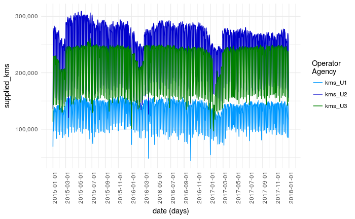

```r
kms_plot_byUN1_2_3 <- ggplot(kms_UN1_2_3, aes(x=kms_UN1_2_3$DATE, y=kms_UN1_2_3$value, group=kms_UN1_2_3$variable)) +
  geom_line(aes(color = kms_UN1_2_3$variable)) +
  scale_color_manual(values = c("#0099ff", "#0000cc", "#008000"),name="Operator\nAgency") +
  xlab("date (days)") +
  ylab("supplied_kms") +
  scale_x_date(date_breaks="2 months") +
  scale_y_continuous(label=scales::comma) +
  theme(axis.text.x = element_text(angle = 90, hjust = 1)) #+
#  coord_fixed(ratio = 1/5000)
kms_plot_byUN1_2_3
```

```r
#ggsave(file.path(plot_path,"kms_plot_byUN1_2_3.pdf"),plot = last_plot(), width = 7, height = 4)
```

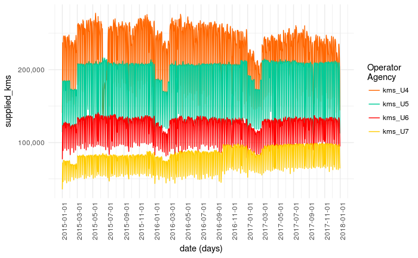

```r
kms_plot_byUN4_5_6_7 <- ggplot(kms_UN4_5_6_7, aes(x=kms_UN4_5_6_7$DATE, y=kms_UN4_5_6_7$value, group=kms_UN4_5_6_7$variable)) +
  geom_line(aes(color = kms_UN4_5_6_7$variable)) +
  scale_color_manual(values = c("#ff6600", "#00cc99", "#ff0000","#ffcc00"),name="Operator\nAgency") +
  xlab("date (days)") +
  ylab("supplied_kms") +
  scale_x_date(date_breaks="2 months") +
  scale_y_continuous(label=scales::comma) +
  theme(axis.text.x = element_text(angle = 90, hjust = 1)) #+
#  coord_fixed(ratio = 1/5000)
kms_plot_byUN4_5_6_7
```

```r
#ggsave(file.path(plot_path,"kms_plot_byUN4_5_6_7.pdf"),plot = last_plot(), width = 7, height = 4)
```